# Supplementary for :

Miss Blandine, Prof Yannick, and the rest (the plebe people)

2025-09-17

# S1. Sample description

The data are in French but have been translated in the article.

Charactéristiques sociodémographiques

|  | Overall (N=2731) |
| --- | --- |
| Sexe |  |
| F | 2119 (77.6%) |
| M | 612 (22.4%) |
| Classe d'âge |  |
| 18-24 | 117 (4.3%) |
| 25-34 | 480 (17.6%) |
| 35-44 | 574 (21.0%) |
| 45-54 | 659 (24.1%) |
| 55-64 | 575 (21.1%) |
| 65-74 | 255 (9.3%) |
| 75+ | 71 (2.6%) |
| age |  |
| Mean (SD) | 47.5 (14.1) |
| Median [Min, Max] | 48.0 [19.0, 91.0] |
| Niveau de diplôme |  |
| Aucun diplôme | 33 (1.2%) |
| Autre diplôme | 40 (1.5%) |
| Baccalauréat ou diplôme équivalent | 436 (16.0%) |
| Certificat d’aptitude professionnelle (CAP) ou Brevet d’études professionnelles (BEP) | 134 (4.9%) |
| Certificat de formation générale (CFG), certificat d’étude primaire, diplôme national du brevet (BEPC ou Brevet des collèges) | 75 (2.7%) |
| Diplôme de niveau Bac+2 (DUT, BTS, DEUG, écoles des formations sanitaires ou sociales...) | 529 (19.4%) |
| Diplôme de second ou troisième cycle universitaire (licence, maîtrise, master, DEA, DESS, doctorat) ou diplômes de grandes écoles | 1484 (54.3%) |
| Situation financière |  |
| A l'équilibre | 607 (22.2%) |
| C'est difficile | 398 (14.6%) |
| Je suis obligé(e) de m'endetter pour m'en sortir | 111 (4.1%) |
| Plûtot Ã l'aise | 580 (21.2%) |
| Très Ã l'aise | 146 (5.3%) |
| Un peu juste, je dois faire attention Ã mes finances | 712 (26.1%) |
| Missing | 177 (6.5%) |
| Statut d'aidant |  |
| Je ne souhaite pas répondre | 45 (1.6%) |
| Non | 2359 (86.4%) |
| Oui | 327 (12.0%) |

Charactéristiques cliniques

|  | Overall (N=2731) |
| --- | --- |
| Diagnostic posé par : |  |
| Par un médecin généraliste | 1039 (38.0%) |
| Par un psychiatre | 1692 (62.0%) |
| Nombre d'épisodes |  |
| 1 | 281 (10.3%) |
| 2 ou 3 | 863 (31.6%) |
| Je ne préfère pas répondre à cette question | 7 (0.3%) |
| Je ne sais pas | 196 (7.2%) |
| Plus de 3 | 1384 (50.7%) |
| Age au 1er épisode |  |
| Mean (SD) | 23.2 (12.0) |
| Median [Min, Max] | 20.0 [0, 73.0] |
| Durée de l'épisode en cours (mois) |  |
| Mean (SD) | 58.7 (93.1) |
| Median [Min, Max] | 27.0 [0, 1490] |
| Missing | 21 (0.8%) |
| Comorbidités somatiques |  |
| Mean (SD) | 2.21 (2.72) |
| Median [Min, Max] | 1.00 [0, 21.0] |
| Comorbiditées psy |  |
| Mean (SD) | 0.997 (1.01) |
| Median [Min, Max] | 1.00 [0, 9.00] |
| Nombre d'antidépresseurs |  |
| Mean (SD) | 2.48 (2.39) |
| Median [Min, Max] | 2.00 [0, 24.0] |
| Nombre de Thymorégulateurs |  |
| Mean (SD) | 0.308 (0.694) |
| Median [Min, Max] | 0 [0, 8.00] |
| Nombre d'hospitalisations psy |  |
| 1 à 5 fois | 359 (13.1%) |

[output cut: 72 more lines]

# S2. Variable description

#### Distributional characteristics of the scores used

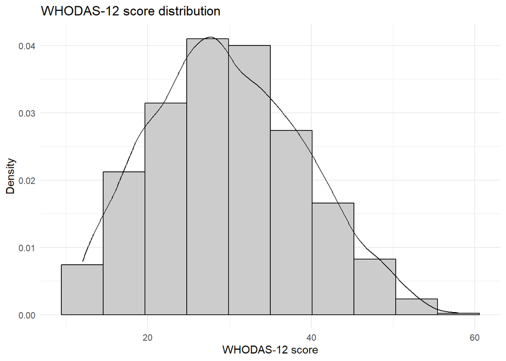

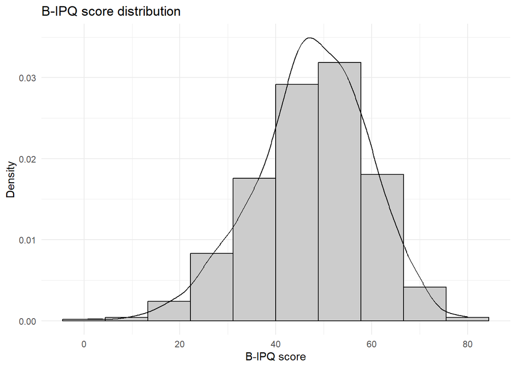

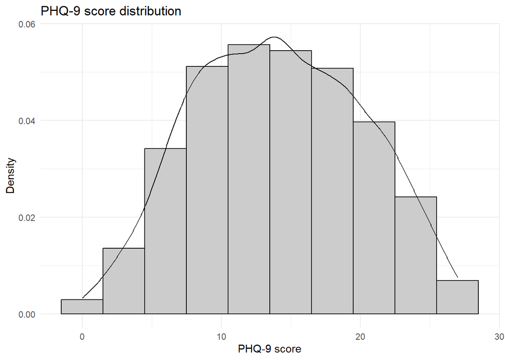

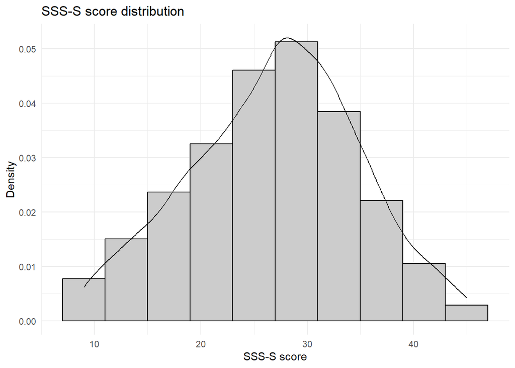

```r
dat$Cognitive_sss <- rowSums(dat[, c("stigma_auto_1", "stigma_auto_2", "stigma_auto_3")])
dat$Affective_sss <- rowSums(dat[, c("stigma_auto_4", "stigma_auto_5", "stigma_auto_6")])
dat$Behavioural_sss <- rowSums(dat[, c("stigma_auto_7", "stigma_auto_8", "stigma_auto_9")])

vars <- c("Cognitive_sss", "Affective_sss", "Behavioural_sss")


# -----------------------------
# 2) Data-visualisation globale avec dfSummary (mini histogrammes + NA, etc.)
# -----------------------------
dfs <- dfSummary(
  dat[vars],
  style      = "grid",
  graph.col  = TRUE,   # mini-graphiques dans la colonne Graph
  valid.col  = TRUE,
  na.col     = TRUE
)


# ou rendu console / HTML
print(dfs, method = "render")
```

Data Frame Summary

dat

**Dimensions**: 2731 x 3  
**Duplicates**: 2015

| **No** | **Variable** | **Stats / Values** | **Freqs (% of Valid)** | **Graph** | **Valid** | **Missing** |
| --- | --- | --- | --- | --- | --- | --- |
| 1 | Cognitive_sss [numeric] | Mean (sd) : 8.9 (2.7) min ≤ med ≤ max: 3 ≤ 9 ≤ 15 IQR (CV) : 4 (0.3) | 13 distinct values |  | 2731 (100.0%) | 0 (0.0%) |
| 2 | Affective_sss [numeric] | Mean (sd) : 9.7 (3.1) min ≤ med ≤ max: 3 ≤ 10 ≤ 15 IQR (CV) : 4 (0.3) | 13 distinct values |  | 2731 (100.0%) | 0 (0.0%) |
| 3 | Behavioural_sss [numeric] | Mean (sd) : 8.4 (2.9) min ≤ med ≤ max: 3 ≤ 9 ≤ 15 IQR (CV) : 4 (0.3) | 13 distinct values |  | 2731 (100.0%) | 0 (0.0%) |

Generated by summarytools 1.1.4 ([R](https://www.r-project.org/) version 4.5.2)  
2026-11-17

# S3. Internal consistency

## B-IPQ

### Items Distribution

Data Frame Summary

data_efa

**Dimensions**: 2731 x 8  
**Duplicates**: 18

| **No** | **Variable** | **Stats / Values** | **Freqs (% of Valid)** | **Graph** | **Valid** | **Missing** |
| --- | --- | --- | --- | --- | --- | --- |
| 1 | item 1 [numeric] | Mean (sd) : 6.7 (2.3) min ≤ med ≤ max: 0 ≤ 7 ≤ 10 IQR (CV) : 3 (0.3) | 11 distinct values |  | 2731 (100.0%) | 0 (0.0%) |
| 2 | item 2 [numeric] | Mean (sd) : 7.1 (2.5) min ≤ med ≤ max: 0 ≤ 8 ≤ 10 IQR (CV) : 4 (0.4) | 11 distinct values |  | 2731 (100.0%) | 0 (0.0%) |
| 3 | item 3 [numeric] | Mean (sd) : 5.6 (2.5) min ≤ med ≤ max: 0 ≤ 5 ≤ 10 IQR (CV) : 4 (0.4) | 11 distinct values |  | 2731 (100.0%) | 0 (0.0%) |
| 4 | item 4 [numeric] | Mean (sd) : 4.6 (3) min ≤ med ≤ max: 0 ≤ 4 ≤ 10 IQR (CV) : 5 (0.7) | 11 distinct values |  | 2731 (100.0%) | 0 (0.0%) |
| 5 | item 5 [numeric] | Mean (sd) : 6.2 (2.3) min ≤ med ≤ max: 0 ≤ 7 ≤ 10 IQR (CV) : 3 (0.4) | 11 distinct values |  | 2731 (100.0%) | 0 (0.0%) |
| 6 | item 6 [numeric] | Mean (sd) : 6.6 (2.7) min ≤ med ≤ max: 0 ≤ 7 ≤ 10 IQR (CV) : 4 (0.4) | 11 distinct values |  | 2731 (100.0%) | 0 (0.0%) |
| 7 | item 7 [numeric] | Mean (sd) : 3.8 (2.6) min ≤ med ≤ max: 0 ≤ 3 ≤ 10 IQR (CV) : 3 (0.7) | 11 distinct values |  | 2731 (100.0%) | 0 (0.0%) |
| 8 | item 8 [numeric] | Mean (sd) : 6.9 (2.5) min ≤ med ≤ max: 0 ≤ 7 ≤ 10 IQR (CV) : 4 (0.4) | 11 distinct values |  | 2731 (100.0%) | 0 (0.0%) |

Generated by summarytools 1.1.4 ([R](https://www.r-project.org/) version 4.5.2)  
2026-11-17

### Skewness and kurtosis

| variable | skewness | kurtosis |
| --- | --- | --- |
| item 1 | -0.63 | -0.13 |
| item 2 | -0.65 | -0.43 |
| item 3 | 0.05 | -0.82 |
| item 4 | 0.39 | -0.88 |
| item 5 | -0.43 | -0.31 |
| item 6 | -0.58 | -0.52 |
| item 7 | 0.53 | -0.54 |
| item 8 | -0.82 | 0.07 |

### ICC

|  | item 1 | item 2 | item 3 | item 4 | item 5 | item 6 | item 7 | item 8 |
| --- | --- | --- | --- | --- | --- | --- | --- | --- |
| item 1 | 1.00 | 0.43 | 0.31 | 0.04 | 0.70 | 0.62 | -0.01 | 0.59 |
| item 2 | 0.43 | 1.00 | 0.20 | 0.03 | 0.40 | 0.34 | -0.01 | 0.33 |
| item 3 | 0.31 | 0.20 | 1.00 | 0.23 | 0.27 | 0.25 | 0.26 | 0.21 |
| item 4 | 0.04 | 0.03 | 0.23 | 1.00 | 0.03 | -0.03 | 0.16 | 0.09 |
| item 5 | 0.70 | 0.40 | 0.27 | 0.03 | 1.00 | 0.64 | -0.04 | 0.59 |
| item 6 | 0.62 | 0.34 | 0.25 | -0.03 | 0.64 | 1.00 | 0.02 | 0.61 |
| item 7 | -0.01 | -0.01 | 0.26 | 0.16 | -0.04 | 0.02 | 1.00 | -0.04 |
| item 8 | 0.59 | 0.33 | 0.21 | 0.09 | 0.59 | 0.61 | -0.04 | 1.00 |

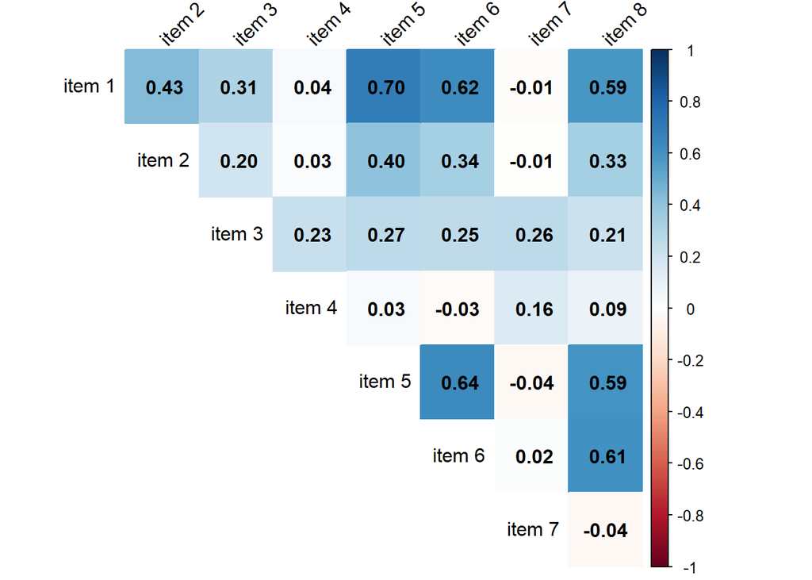

### ITC

| item | mean | sd | r_drop | alpha_if_deleted |
| --- | --- | --- | --- | --- |
| item 1 | 6.740388 | 2.255066 | 0.6619231 | 0.6439679 |
| item 2 | 7.069938 | 2.549700 | 0.4316221 | 0.6870525 |
| item 3 | 5.558037 | 2.476228 | 0.4065441 | 0.6923264 |
| item 4 | 4.588063 | 2.986144 | 0.0854831 | 0.7666672 |
| item 5 | 6.237642 | 2.292428 | 0.6388410 | 0.6476197 |
| item 6 | 6.564262 | 2.674084 | 0.5791216 | 0.6532901 |
| item 7 | 3.751373 | 2.602773 | 0.0876937 | 0.7556187 |
| item 8 | 6.898206 | 2.510177 | 0.5760041 | 0.6563860 |

### Floor ceiling

Item-level descriptive statistics and floor/ceiling effects of the B-IPQ

| item | n | min | max | mean | sd | Floor | Ceiling |
| --- | --- | --- | --- | --- | --- | --- | --- |
| item 1 | 2731 | 0 | 10 | 6.74 | 2.26 | 0.5 | 11.0 |
| item 2 | 2731 | 0 | 10 | 7.07 | 2.55 | 1.0 | 23.5 |
| item 3 | 2731 | 0 | 10 | 5.56 | 2.48 | 1.0 | 7.4 |
| item 4 | 2731 | 0 | 10 | 4.59 | 2.99 | 7.1 | 10.8 |
| item 5 | 2731 | 0 | 10 | 6.24 | 2.29 | 1.0 | 7.2 |
| item 6 | 2731 | 0 | 10 | 6.56 | 2.67 | 2.0 | 16.0 |
| item 7 | 2731 | 0 | 10 | 3.75 | 2.60 | 9.6 | 2.1 |
| item 8 | 2731 | 0 | 10 | 6.90 | 2.51 | 1.8 | 16.1 |

## PHQ-9

### Items Distribution

Data Frame Summary

data_efa_phq

**Dimensions**: 2731 x 9  
**Duplicates**: 591

| **No** | **Variable** | **Stats / Values** | **Freqs (% of Valid)** | **Graph** | **Valid** | **Missing** |
| --- | --- | --- | --- | --- | --- | --- |
| 1 | item 1 [numeric] | Mean (sd) : 1.6 (1) min ≤ med ≤ max: 0 ≤ 1 ≤ 3 IQR (CV) : 2 (0.6) | 0 : 327 ( 12.0% ) 1 : 1117 ( 40.9% ) 2 : 512 ( 18.7% ) 3 : 775 ( 28.4% ) |  | 2731 (100.0%) | 0 (0.0%) |
| 2 | item 2 [numeric] | Mean (sd) : 1.6 (1) min ≤ med ≤ max: 0 ≤ 1 ≤ 3 IQR (CV) : 1.5 (0.6) | 0 : 258 ( 9.4% ) 1 : 1246 ( 45.6% ) 2 : 544 ( 19.9% ) 3 : 683 ( 25.0% ) |  | 2731 (100.0%) | 0 (0.0%) |
| 3 | item 3 [numeric] | Mean (sd) : 2.1 (1) min ≤ med ≤ max: 0 ≤ 2 ≤ 3 IQR (CV) : 2 (0.5) | 0 : 210 ( 7.7% ) 1 : 723 ( 26.5% ) 2 : 477 ( 17.5% ) 3 : 1321 ( 48.4% ) |  | 2731 (100.0%) | 0 (0.0%) |
| 4 | item 4 [numeric] | Mean (sd) : 2.3 (0.9) min ≤ med ≤ max: 0 ≤ 3 ≤ 3 IQR (CV) : 2 (0.4) | 0 : 75 ( 2.7% ) 1 : 609 ( 22.3% ) 2 : 523 ( 19.2% ) 3 : 1524 ( 55.8% ) |  | 2731 (100.0%) | 0 (0.0%) |
| 5 | item 5 [numeric] | Mean (sd) : 1.7 (1.1) min ≤ med ≤ max: 0 ≤ 2 ≤ 3 IQR (CV) : 2 (0.7) | 0 : 471 ( 17.2% ) 1 : 798 ( 29.2% ) 2 : 570 ( 20.9% ) 3 : 892 ( 32.7% ) |  | 2731 (100.0%) | 0 (0.0%) |
| 6 | item 6 [numeric] | Mean (sd) : 1.8 (1.1) min ≤ med ≤ max: 0 ≤ 2 ≤ 3 IQR (CV) : 2 (0.6) | 0 : 391 ( 14.3% ) 1 : 844 ( 30.9% ) 2 : 505 ( 18.5% ) 3 : 991 ( 36.3% ) |  | 2731 (100.0%) | 0 (0.0%) |
| 7 | item 7 [numeric] | Mean (sd) : 1.6 (1.1) min ≤ med ≤ max: 0 ≤ 1 ≤ 3 IQR (CV) : 2 (0.7) | 0 : 492 ( 18.0% ) 1 : 924 ( 33.8% ) 2 : 586 ( 21.5% ) 3 : 729 ( 26.7% ) |  | 2731 (100.0%) | 0 (0.0%) |
| 8 | item 8 [numeric] | Mean (sd) : 0.7 (0.9) min ≤ med ≤ max: 0 ≤ 0 ≤ 3 IQR (CV) : 1 (1.3) | 0 : 1475 ( 54.0% ) 1 : 792 ( 29.0% ) 2 : 276 ( 10.1% ) 3 : 188 ( 6.9% ) |  | 2731 (100.0%) | 0 (0.0%) |
| 9 | item 9 [numeric] | Mean (sd) : 0.8 (0.9) min ≤ med ≤ max: 0 ≤ 1 ≤ 3 IQR (CV) : 1 (1.2) | 0 : 1306 ( 47.8% ) 1 : 936 ( 34.3% ) 2 : 246 ( 9.0% ) 3 : 243 ( 8.9% ) |  | 2731 (100.0%) | 0 (0.0%) |

Generated by summarytools 1.1.4 ([R](https://www.r-project.org/) version 4.5.2)  
2026-11-17

### Skewness and kurtosis

| variable | skewness | kurtosis |
| --- | --- | --- |
| item 1 | 0.10 | -1.23 |
| item 2 | 0.22 | -1.10 |
| item 3 | -0.56 | -1.09 |
| item 4 | -0.80 | -0.74 |
| item 5 | -0.14 | -1.34 |
| item 6 | -0.19 | -1.35 |
| item 7 | 0.04 | -1.27 |
| item 8 | 1.18 | 0.45 |
| item 9 | 1.07 | 0.23 |

### ICC

|  | item 1 | item 2 | item 3 | item 4 | item 5 | item 6 | item 7 | item 8 | item 9 |
| --- | --- | --- | --- | --- | --- | --- | --- | --- | --- |
| item 1 | 1.00 | 0.65 | 0.35 | 0.43 | 0.37 | 0.44 | 0.40 | 0.26 | 0.42 |
| item 2 | 0.65 | 1.00 | 0.36 | 0.43 | 0.37 | 0.54 | 0.40 | 0.28 | 0.51 |
| item 3 | 0.35 | 0.36 | 1.00 | 0.46 | 0.38 | 0.32 | 0.35 | 0.24 | 0.27 |
| item 4 | 0.43 | 0.43 | 0.46 | 1.00 | 0.41 | 0.33 | 0.43 | 0.27 | 0.27 |
| item 5 | 0.37 | 0.37 | 0.38 | 0.41 | 1.00 | 0.37 | 0.40 | 0.28 | 0.30 |
| item 6 | 0.44 | 0.54 | 0.32 | 0.33 | 0.37 | 1.00 | 0.41 | 0.28 | 0.46 |
| item 7 | 0.40 | 0.40 | 0.35 | 0.43 | 0.40 | 0.41 | 1.00 | 0.39 | 0.31 |
| item 8 | 0.26 | 0.28 | 0.24 | 0.27 | 0.28 | 0.28 | 0.39 | 1.00 | 0.28 |
| item 9 | 0.42 | 0.51 | 0.27 | 0.27 | 0.30 | 0.46 | 0.31 | 0.28 | 1.00 |

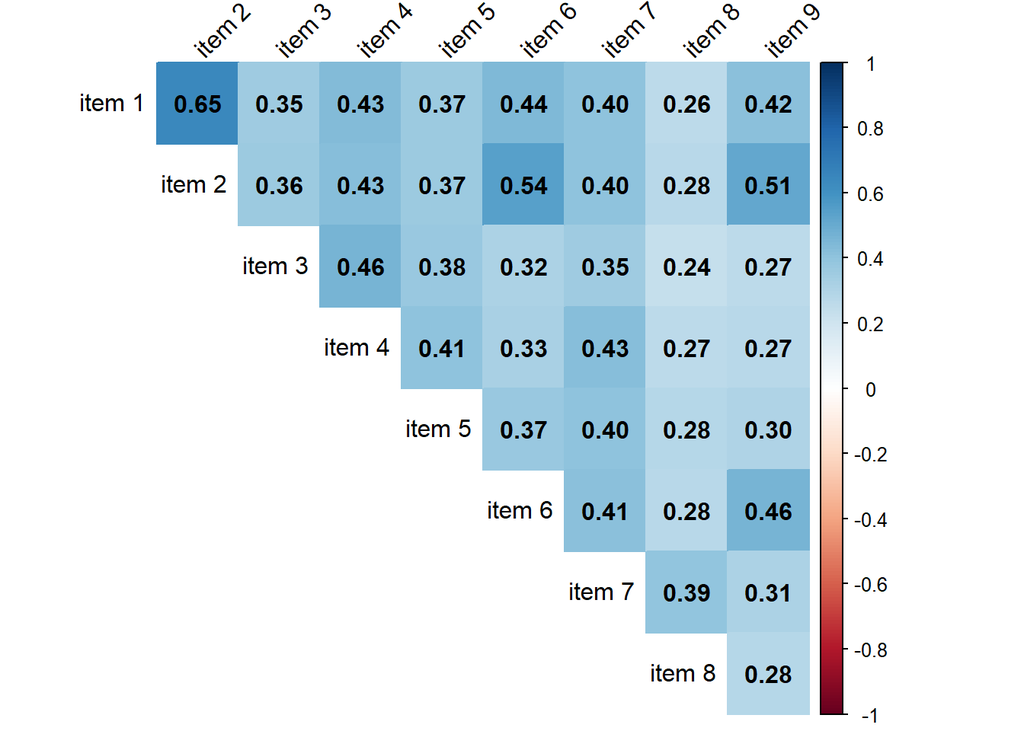

### ITC

| item | mean | sd | r_drop | alpha_if_deleted |
| --- | --- | --- | --- | --- |
| item 1 | 1.6352984 | 1.0193651 | 0.6222074 | 0.8206179 |
| item 2 | 1.6049066 | 0.9635660 | 0.6722023 | 0.8158470 |
| item 3 | 2.0651776 | 1.0257488 | 0.5003327 | 0.8338030 |
| item 4 | 2.2801172 | 0.9015067 | 0.5691528 | 0.8269290 |
| item 5 | 1.6894910 | 1.1012295 | 0.5361881 | 0.8304743 |
| item 6 | 1.7674844 | 1.0913165 | 0.5859551 | 0.8246355 |
| item 7 | 1.5682900 | 1.0676759 | 0.5810926 | 0.8251263 |
| item 8 | 0.6986452 | 0.9088464 | 0.4389676 | 0.8391332 |
| item 9 | 0.7898206 | 0.9382700 | 0.5243580 | 0.8310739 |

### Floor ceiling

Item-level descriptive statistics and floor/ceiling effects of the PHQ-9

| item | n | min | max | mean | sd | Floor | Ceiling |
| --- | --- | --- | --- | --- | --- | --- | --- |
| item 1 | 2731 | 0 | 3 | 1.64 | 1.02 | 12.0 | 28.4 |
| item 2 | 2731 | 0 | 3 | 1.60 | 0.96 | 9.4 | 25.0 |
| item 3 | 2731 | 0 | 3 | 2.07 | 1.03 | 7.7 | 48.4 |
| item 4 | 2731 | 0 | 3 | 2.28 | 0.90 | 2.7 | 55.8 |
| item 5 | 2731 | 0 | 3 | 1.69 | 1.10 | 17.2 | 32.7 |
| item 6 | 2731 | 0 | 3 | 1.77 | 1.09 | 14.3 | 36.3 |
| item 7 | 2731 | 0 | 3 | 1.57 | 1.07 | 18.0 | 26.7 |
| item 8 | 2731 | 0 | 3 | 0.70 | 0.91 | 54.0 | 6.9 |
| item 9 | 2731 | 0 | 3 | 0.79 | 0.94 | 47.8 | 8.9 |

## WHODAS-12

### Items Distribution

Data Frame Summary

data_efa_who

**Dimensions**: 2731 x 12  
**Duplicates**: 104

| **No** | **Variable** | **Stats / Values** | **Freqs (% of Valid)** | **Graph** | **Valid** | **Missing** |
| --- | --- | --- | --- | --- | --- | --- |
| 1 | item 1 [numeric] | Mean (sd) : 2.5 (1.2) min ≤ med ≤ max: 1 ≤ 2 ≤ 5 IQR (CV) : 2 (0.5) | 1 : 823 ( 30.1% ) 2 : 582 ( 21.3% ) 3 : 695 ( 25.4% ) 4 : 513 ( 18.8% ) 5 : 118 ( 4.3% ) |  | 2731 (100.0%) | 0 (0.0%) |
| 2 | item 2 [numeric] | Mean (sd) : 2.8 (1) min ≤ med ≤ max: 1 ≤ 3 ≤ 5 IQR (CV) : 2 (0.4) | 1 : 325 ( 11.9% ) 2 : 633 ( 23.2% ) 3 : 1053 ( 38.6% ) 4 : 630 ( 23.1% ) 5 : 90 ( 3.3% ) |  | 2731 (100.0%) | 0 (0.0%) |
| 3 | item 3 [numeric] | Mean (sd) : 2.3 (1.1) min ≤ med ≤ max: 1 ≤ 2 ≤ 5 IQR (CV) : 2 (0.5) | 1 : 908 ( 33.2% ) 2 : 722 ( 26.4% ) 3 : 656 ( 24.0% ) 4 : 354 ( 13.0% ) 5 : 91 ( 3.3% ) |  | 2731 (100.0%) | 0 (0.0%) |
| 4 | item 4 [numeric] | Mean (sd) : 3 (1.3) min ≤ med ≤ max: 1 ≤ 3 ≤ 5 IQR (CV) : 2 (0.4) | 1 : 438 ( 16.0% ) 2 : 546 ( 20.0% ) 3 : 735 ( 26.9% ) 4 : 668 ( 24.5% ) 5 : 344 ( 12.6% ) |  | 2731 (100.0%) | 0 (0.0%) |
| 5 | item 5 [numeric] | Mean (sd) : 3.2 (1) min ≤ med ≤ max: 1 ≤ 3 ≤ 5 IQR (CV) : 1 (0.3) | 1 : 161 ( 5.9% ) 2 : 493 ( 18.1% ) 3 : 978 ( 35.8% ) 4 : 922 ( 33.8% ) 5 : 177 ( 6.5% ) |  | 2731 (100.0%) | 0 (0.0%) |
| 6 | item 6 [numeric] | Mean (sd) : 2.4 (1.1) min ≤ med ≤ max: 1 ≤ 2 ≤ 5 IQR (CV) : 1 (0.4) | 1 : 666 ( 24.4% ) 2 : 735 ( 26.9% ) 3 : 839 ( 30.7% ) 4 : 450 ( 16.5% ) 5 : 41 ( 1.5% ) |  | 2731 (100.0%) | 0 (0.0%) |
| 7 | item 7 [numeric] | Mean (sd) : 2.4 (1.3) min ≤ med ≤ max: 1 ≤ 2 ≤ 5 IQR (CV) : 2 (0.6) | 1 : 1025 ( 37.5% ) 2 : 556 ( 20.4% ) 3 : 523 ( 19.2% ) 4 : 396 ( 14.5% ) 5 : 231 ( 8.5% ) |  | 2731 (100.0%) | 0 (0.0%) |
| 8 | item 8 [numeric] | Mean (sd) : 1.7 (1) min ≤ med ≤ max: 1 ≤ 1 ≤ 5 IQR (CV) : 1 (0.6) | 1 : 1561 ( 57.2% ) 2 : 555 ( 20.3% ) 3 : 395 ( 14.5% ) 4 : 180 ( 6.6% ) 5 : 40 ( 1.5% ) |  | 2731 (100.0%) | 0 (0.0%) |
| 9 | item 9 [numeric] | Mean (sd) : 1.6 (0.9) min ≤ med ≤ max: 1 ≤ 1 ≤ 5 IQR (CV) : 1 (0.5) | 1 : 1594 ( 58.4% ) 2 : 686 ( 25.1% ) 3 : 361 ( 13.2% ) 4 : 78 ( 2.9% ) 5 : 12 ( 0.4% ) |  | 2731 (100.0%) | 0 (0.0%) |
| 10 | item 10 [numeric] | Mean (sd) : 2.4 (1.2) min ≤ med ≤ max: 1 ≤ 2 ≤ 5 IQR (CV) : 2 (0.5) | 1 : 824 ( 30.2% ) 2 : 702 ( 25.7% ) 3 : 678 ( 24.8% ) 4 : 400 ( 14.6% ) 5 : 127 ( 4.7% ) |  | 2731 (100.0%) | 0 (0.0%) |
| 11 | item 11 [numeric] | Mean (sd) : 2.6 (1.2) min ≤ med ≤ max: 1 ≤ 3 ≤ 5 IQR (CV) : 1 (0.5) | 1 : 621 ( 22.7% ) 2 : 664 ( 24.3% ) 3 : 774 ( 28.3% ) 4 : 512 ( 18.7% ) 5 : 160 ( 5.9% ) |  | 2731 (100.0%) | 0 (0.0%) |
| 12 | item 12 [numeric] | Mean (sd) : 3 (1.4) min ≤ med ≤ max: 1 ≤ 3 ≤ 5 IQR (CV) : 2 (0.5) | 1 : 585 ( 21.4% ) 2 : 450 ( 16.5% ) 3 : 633 ( 23.2% ) 4 : 483 ( 17.7% ) 5 : 580 ( 21.2% ) |  | 2731 (100.0%) | 0 (0.0%) |

Generated by summarytools 1.1.4 ([R](https://www.r-project.org/) version 4.5.2)  
2026-11-17

### Skewness and kurtosis

| variable | skewness | kurtosis |
| --- | --- | --- |
| item 1 | 0.27 | -1.07 |
| item 10 | 0.43 | -0.82 |
| item 11 | 0.19 | -0.93 |
| item 12 | -0.02 | -1.29 |
| item 2 | -0.14 | -0.59 |
| item 3 | 0.51 | -0.73 |
| item 4 | -0.06 | -1.02 |
| item 5 | -0.31 | -0.39 |
| item 6 | 0.15 | -0.96 |
| item 7 | 0.54 | -0.95 |
| item 8 | 1.21 | 0.51 |
| item 9 | 1.26 | 0.93 |

### ICC

|  | item 1 | item 2 | item 3 | item 4 | item 5 | item 6 | item 7 | item 8 | item 9 | item 10 | item 11 | item 12 |
| --- | --- | --- | --- | --- | --- | --- | --- | --- | --- | --- | --- | --- |
| item 1 | 1.00 | 0.47 | 0.35 | 0.35 | 0.35 | 0.34 | 0.70 | 0.43 | 0.42 | 0.18 | 0.16 | 0.31 |
| item 2 | 0.47 | 1.00 | 0.51 | 0.52 | 0.50 | 0.50 | 0.46 | 0.46 | 0.45 | 0.39 | 0.41 | 0.51 |
| item 3 | 0.35 | 0.51 | 1.00 | 0.55 | 0.45 | 0.50 | 0.35 | 0.36 | 0.38 | 0.49 | 0.40 | 0.45 |
| item 4 | 0.35 | 0.52 | 0.55 | 1.00 | 0.47 | 0.41 | 0.37 | 0.36 | 0.37 | 0.54 | 0.53 | 0.49 |
| item 5 | 0.35 | 0.50 | 0.45 | 0.47 | 1.00 | 0.44 | 0.34 | 0.30 | 0.32 | 0.38 | 0.38 | 0.45 |
| item 6 | 0.34 | 0.50 | 0.50 | 0.41 | 0.44 | 1.00 | 0.35 | 0.34 | 0.35 | 0.39 | 0.36 | 0.43 |
| item 7 | 0.70 | 0.46 | 0.35 | 0.37 | 0.34 | 0.35 | 1.00 | 0.48 | 0.46 | 0.20 | 0.20 | 0.31 |
| item 8 | 0.43 | 0.46 | 0.36 | 0.36 | 0.30 | 0.34 | 0.48 | 1.00 | 0.74 | 0.29 | 0.28 | 0.31 |
| item 9 | 0.42 | 0.45 | 0.38 | 0.37 | 0.32 | 0.35 | 0.46 | 0.74 | 1.00 | 0.30 | 0.27 | 0.31 |
| item 10 | 0.18 | 0.39 | 0.49 | 0.54 | 0.38 | 0.39 | 0.20 | 0.29 | 0.30 | 1.00 | 0.51 | 0.40 |
| item 11 | 0.16 | 0.41 | 0.40 | 0.53 | 0.38 | 0.36 | 0.20 | 0.28 | 0.27 | 0.51 | 1.00 | 0.41 |
| item 12 | 0.31 | 0.51 | 0.45 | 0.49 | 0.45 | 0.43 | 0.31 | 0.31 | 0.31 | 0.40 | 0.41 | 1.00 |

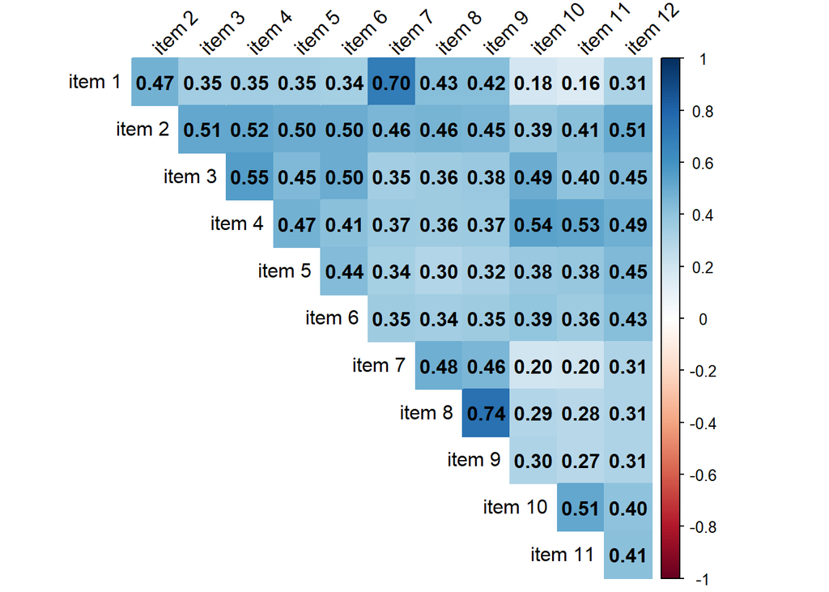

### ITC

| item | mean | sd | r_drop | alpha_if_deleted |
| --- | --- | --- | --- | --- |
| item 1 | 2.458440 | 1.2192042 | 0.5392549 | 0.8804547 |
| item 2 | 2.826803 | 1.0201411 | 0.7112941 | 0.8716424 |
| item 3 | 2.266935 | 1.1490407 | 0.6578555 | 0.8736197 |
| item 4 | 2.975833 | 1.2609092 | 0.6804073 | 0.8719968 |
| item 5 | 3.168803 | 0.9924960 | 0.5888444 | 0.8778690 |
| item 6 | 2.437935 | 1.0742115 | 0.5932818 | 0.8773537 |
| item 7 | 2.359941 | 1.3338613 | 0.5547233 | 0.8801570 |
| item 8 | 1.748810 | 1.0241916 | 0.5740953 | 0.8784648 |
| item 9 | 1.618821 | 0.8512418 | 0.5912241 | 0.8786866 |
| item 10 | 2.378982 | 1.1879668 | 0.5534263 | 0.8795300 |
| item 11 | 2.606737 | 1.1917968 | 0.5233336 | 0.8812544 |
| item 12 | 3.008422 | 1.4313095 | 0.5865244 | 0.8788138 |

### Floor ceiling

| item | n | min | max | mean | sd | Floor | Ceiling |
| --- | --- | --- | --- | --- | --- | --- | --- |
| item 1 | 2731 | 1 | 5 | 2.46 | 1.22 | 30.1 | 4.3 |
| item 2 | 2731 | 1 | 5 | 2.83 | 1.02 | 11.9 | 3.3 |
| item 3 | 2731 | 1 | 5 | 2.27 | 1.15 | 33.2 | 3.3 |
| item 4 | 2731 | 1 | 5 | 2.98 | 1.26 | 16.0 | 12.6 |
| item 5 | 2731 | 1 | 5 | 3.17 | 0.99 | 5.9 | 6.5 |
| item 6 | 2731 | 1 | 5 | 2.44 | 1.07 | 24.4 | 1.5 |
| item 7 | 2731 | 1 | 5 | 2.36 | 1.33 | 37.5 | 8.5 |
| item 8 | 2731 | 1 | 5 | 1.75 | 1.02 | 57.2 | 1.5 |
| item 9 | 2731 | 1 | 5 | 1.62 | 0.85 | 58.4 | 0.4 |
| item 10 | 2731 | 1 | 5 | 2.38 | 1.19 | 30.2 | 4.7 |
| item 11 | 2731 | 1 | 5 | 2.61 | 1.19 | 22.7 | 5.9 |
| item 12 | 2731 | 1 | 5 | 3.01 | 1.43 | 21.4 | 21.2 |

## SSS-S

### Items Distribution

Data Frame Summary

data_efa_sss

**Dimensions**: 2731 x 9  
**Duplicates**: 343

| **No** | **Variable** | **Stats / Values** | **Freqs (% of Valid)** | **Graph** | **Valid** | **Missing** |
| --- | --- | --- | --- | --- | --- | --- |
| 1 | item 1 [numeric] | Mean (sd) : 3 (1.2) min ≤ med ≤ max: 1 ≤ 3 ≤ 5 IQR (CV) : 2 (0.4) | 1 : 365 ( 13.4% ) 2 : 542 ( 19.8% ) 3 : 912 ( 33.4% ) 4 : 626 ( 22.9% ) 5 : 286 ( 10.5% ) |  | 2731 (100.0%) | 0 (0.0%) |
| 2 | item 2 [numeric] | Mean (sd) : 3.4 (1.1) min ≤ med ≤ max: 1 ≤ 4 ≤ 5 IQR (CV) : 1 (0.3) | 1 : 170 ( 6.2% ) 2 : 346 ( 12.7% ) 3 : 770 ( 28.2% ) 4 : 1017 ( 37.2% ) 5 : 428 ( 15.7% ) |  | 2731 (100.0%) | 0 (0.0%) |
| 3 | item 3 [numeric] | Mean (sd) : 2.5 (1.2) min ≤ med ≤ max: 1 ≤ 2 ≤ 5 IQR (CV) : 2 (0.5) | 1 : 747 ( 27.4% ) 2 : 699 ( 25.6% ) 3 : 743 ( 27.2% ) 4 : 375 ( 13.7% ) 5 : 167 ( 6.1% ) |  | 2731 (100.0%) | 0 (0.0%) |
| 4 | item 4 [numeric] | Mean (sd) : 3 (1.4) min ≤ med ≤ max: 1 ≤ 3 ≤ 5 IQR (CV) : 2 (0.4) | 1 : 518 ( 19.0% ) 2 : 495 ( 18.1% ) 3 : 551 ( 20.2% ) 4 : 746 ( 27.3% ) 5 : 421 ( 15.4% ) |  | 2731 (100.0%) | 0 (0.0%) |
| 5 | item 5 [numeric] | Mean (sd) : 3.6 (1.2) min ≤ med ≤ max: 1 ≤ 4 ≤ 5 IQR (CV) : 1 (0.3) | 1 : 212 ( 7.8% ) 2 : 282 ( 10.3% ) 3 : 524 ( 19.2% ) 4 : 1108 ( 40.6% ) 5 : 605 ( 22.2% ) |  | 2731 (100.0%) | 0 (0.0%) |
| 6 | item 6 [numeric] | Mean (sd) : 3.1 (1.3) min ≤ med ≤ max: 1 ≤ 3 ≤ 5 IQR (CV) : 2 (0.4) | 1 : 401 ( 14.7% ) 2 : 470 ( 17.2% ) 3 : 660 ( 24.2% ) 4 : 832 ( 30.5% ) 5 : 368 ( 13.5% ) |  | 2731 (100.0%) | 0 (0.0%) |
| 7 | item 7 [numeric] | Mean (sd) : 3 (1.2) min ≤ med ≤ max: 1 ≤ 3 ≤ 5 IQR (CV) : 2 (0.4) | 1 : 341 ( 12.5% ) 2 : 619 ( 22.7% ) 3 : 831 ( 30.4% ) 4 : 662 ( 24.2% ) 5 : 278 ( 10.2% ) |  | 2731 (100.0%) | 0 (0.0%) |
| 8 | item 8 [numeric] | Mean (sd) : 2.7 (1.2) min ≤ med ≤ max: 1 ≤ 3 ≤ 5 IQR (CV) : 2 (0.4) | 1 : 476 ( 17.4% ) 2 : 645 ( 23.6% ) 3 : 905 ( 33.1% ) 4 : 498 ( 18.2% ) 5 : 207 ( 7.6% ) |  | 2731 (100.0%) | 0 (0.0%) |
| 9 | item 9 [numeric] | Mean (sd) : 2.7 (1.2) min ≤ med ≤ max: 1 ≤ 3 ≤ 5 IQR (CV) : 2 (0.4) | 1 : 534 ( 19.6% ) 2 : 684 ( 25.0% ) 3 : 714 ( 26.1% ) 4 : 610 ( 22.3% ) 5 : 189 ( 6.9% ) |  | 2731 (100.0%) | 0 (0.0%) |

Generated by summarytools 1.1.4 ([R](https://www.r-project.org/) version 4.5.2)  
2026-11-17

### Skewness and kurtosis

| variable | skewness | kurtosis |
| --- | --- | --- |
| item 1 | -0.05 | -0.78 |
| item 2 | -0.49 | -0.36 |
| item 3 | 0.40 | -0.77 |
| item 4 | -0.12 | -1.22 |
| item 5 | -0.73 | -0.25 |
| item 6 | -0.24 | -1.00 |
| item 7 | -0.03 | -0.84 |
| item 8 | 0.12 | -0.77 |
| item 9 | 0.12 | -0.99 |

### ICC

|  | item 1 | item 2 | item 3 | item 4 | item 5 | item 6 | item 7 | item 8 | item 9 |
| --- | --- | --- | --- | --- | --- | --- | --- | --- | --- |
| item 1 | 1.00 | 0.38 | 0.46 | 0.54 | 0.42 | 0.31 | 0.25 | 0.45 | 0.30 |
| item 2 | 0.38 | 1.00 | 0.43 | 0.43 | 0.56 | 0.39 | 0.36 | 0.48 | 0.37 |
| item 3 | 0.46 | 0.43 | 1.00 | 0.54 | 0.46 | 0.57 | 0.42 | 0.53 | 0.58 |
| item 4 | 0.54 | 0.43 | 0.54 | 1.00 | 0.61 | 0.46 | 0.40 | 0.54 | 0.41 |
| item 5 | 0.42 | 0.56 | 0.46 | 0.61 | 1.00 | 0.46 | 0.43 | 0.56 | 0.40 |
| item 6 | 0.31 | 0.39 | 0.57 | 0.46 | 0.46 | 1.00 | 0.47 | 0.47 | 0.72 |
| item 7 | 0.25 | 0.36 | 0.42 | 0.40 | 0.43 | 0.47 | 1.00 | 0.47 | 0.46 |
| item 8 | 0.45 | 0.48 | 0.53 | 0.54 | 0.56 | 0.47 | 0.47 | 1.00 | 0.49 |
| item 9 | 0.30 | 0.37 | 0.58 | 0.41 | 0.40 | 0.72 | 0.46 | 0.49 | 1.00 |

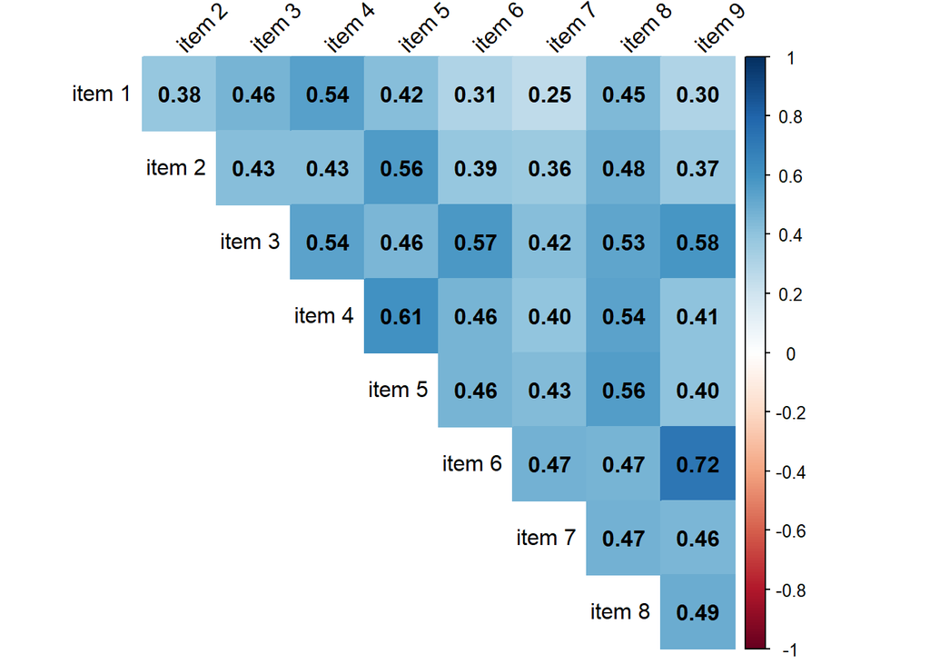

### ITC

| item | mean | sd | r_drop | alpha_if_deleted |
| --- | --- | --- | --- | --- |
| item 1 | 2.972904 | 1.175139 | 0.5372144 | 0.8853906 |
| item 2 | 3.434639 | 1.089255 | 0.5957407 | 0.8807987 |
| item 3 | 2.456609 | 1.198841 | 0.7014905 | 0.8722348 |
| item 4 | 3.020872 | 1.352763 | 0.6813119 | 0.8740516 |
| item 5 | 3.590260 | 1.165201 | 0.6861440 | 0.8736355 |
| item 6 | 3.108385 | 1.261710 | 0.6774810 | 0.8741572 |
| item 7 | 2.969608 | 1.172718 | 0.5671209 | 0.8830521 |
| item 8 | 2.749176 | 1.164680 | 0.6964600 | 0.8728095 |
| item 9 | 2.720249 | 1.206252 | 0.6515664 | 0.8763436 |

### Floor ceiling

| item | n | min | max | mean | sd | Floor | Ceiling |
| --- | --- | --- | --- | --- | --- | --- | --- |
| item 1 | 2731 | 1 | 5 | 2.97 | 1.18 | 13.4 | 10.5 |
| item 2 | 2731 | 1 | 5 | 3.43 | 1.09 | 6.2 | 15.7 |
| item 3 | 2731 | 1 | 5 | 2.46 | 1.20 | 27.4 | 6.1 |
| item 4 | 2731 | 1 | 5 | 3.02 | 1.35 | 19.0 | 15.4 |
| item 5 | 2731 | 1 | 5 | 3.59 | 1.17 | 7.8 | 22.2 |
| item 6 | 2731 | 1 | 5 | 3.11 | 1.26 | 14.7 | 13.5 |
| item 7 | 2731 | 1 | 5 | 2.97 | 1.17 | 12.5 | 10.2 |
| item 8 | 2731 | 1 | 5 | 2.75 | 1.16 | 17.4 | 7.6 |
| item 9 | 2731 | 1 | 5 | 2.72 | 1.21 | 19.6 | 6.9 |

# S4. Structural validity

## B-IPQ

### unidimensional CFA

```r
items_bipq <- paste0("item", 1:8)
cfa_model <- '
BIPQ =~ item1 + item2 + item3 + item4 +
        item5 + item6 + item7 + item8
'
fit_bipq_1f <- cfa(
  cfa_model,
  data = data_efa_bipq,
  estimator = "WLSMV",
  ordered = items_bipq
)
summary(fit_bipq_1f, fit.measures = TRUE, standardized = TRUE, rsquare = TRUE)
```

```
## lavaan 0.6-20 ended normally after 21 iterations
##
##   Estimator                                       DWLS
##   Optimization method                           NLMINB
##   Number of model parameters                        88
##
##   Number of observations                          2731
##
## Model Test User Model:
##                                               Standard      Scaled
##   Test Statistic                               656.482    1186.628
##   Degrees of freedom                                20          20
##   P-value (Chi-square)                           0.000       0.000
##   Scaling correction factor                                  0.555
##   Shift parameter                                            2.907
##     simple second-order correction
##
## Model Test Baseline Model:
##
##   Test statistic                             33944.610   20537.875
##   Degrees of freedom                                28          28
##   P-value                                        0.000       0.000
##   Scaling correction factor                                  1.654
##
## User Model versus Baseline Model:
##
##   Comparative Fit Index (CFI)                    0.981       0.943
##   Tucker-Lewis Index (TLI)                       0.974       0.920
##
##   Robust Comparative Fit Index (CFI)                         0.920
##   Robust Tucker-Lewis Index (TLI)                            0.888
##
## Root Mean Square Error of Approximation:
##
##   RMSEA                                          0.108       0.146
##   90 Percent confidence interval - lower         0.101       0.139
##   90 Percent confidence interval - upper         0.115       0.153
##   P-value H_0: RMSEA <= 0.050                    0.000       0.000
##   P-value H_0: RMSEA >= 0.080                    1.000       1.000
##
```

[output cut: 119 more lines]

```
##    .item6             0.376                               0.376    0.376
##    .item7             1.000                               1.000    1.000
##    .item8             0.432                               0.432    0.432
##     BIPQ              0.719    0.011   65.545    0.000    1.000    1.000
##
## R-Square:
##                    Estimate
##     item1             0.719
##     item2             0.282
##     item3             0.123
##     item4             0.004
##     item5             0.716
##     item6             0.624
##     item7             0.000
##     item8             0.568
```

```r
# Robust fit indices
fitMeasures(
  fit_bipq_1f,
  c(
    "cfi.robust",
    "rmsea.robust",
    "rmsea.ci.lower.robust",
    "rmsea.ci.upper.robust",
    "srmr"
  )
)
```

```
##            cfi.robust          rmsea.robust rmsea.ci.lower.robust
##                 0.920                 0.105                 0.099
## rmsea.ci.upper.robust                  srmr
##                 0.111                 0.067
```

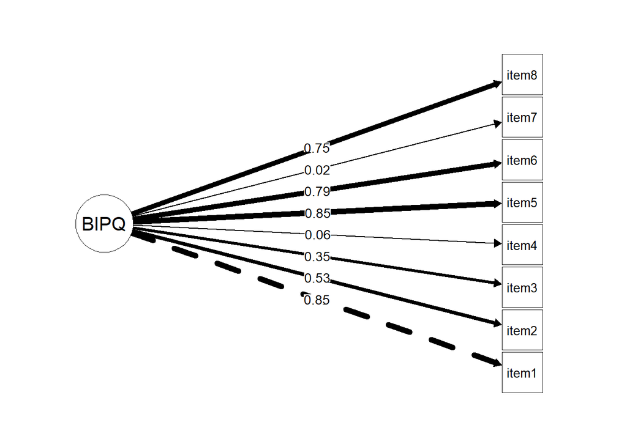

Sensibility analysis with “MLR”

```r
cfa_model <- '
BIPQ =~ item1 + item2 + item3 + item4 +
        item5 + item6 + item7 + item8
'
fit_bipq_1fmlr <- cfa(
  cfa_model,
  data = data_efa_bipq,
  estimator = "MLR"
)
summary(fit_bipq_1fmlr, fit.measures = TRUE, standardized = TRUE, rsquare = TRUE)
```

```
## lavaan 0.6-20 ended normally after 31 iterations
##
##   Estimator                                         ML
##   Optimization method                           NLMINB
##   Number of model parameters                        16
##
##   Number of observations                          2731
##
## Model Test User Model:
##                                               Standard      Scaled
##   Test Statistic                               566.353     467.382
##   Degrees of freedom                                20          20
##   P-value (Chi-square)                           0.000       0.000
##   Scaling correction factor                                  1.212
##     Yuan-Bentler correction (Mplus variant)
##
## Model Test Baseline Model:
##
##   Test statistic                              6995.414    5343.729
##   Degrees of freedom                                28          28
##   P-value                                        0.000       0.000
##   Scaling correction factor                                  1.309
##
## User Model versus Baseline Model:
##
##   Comparative Fit Index (CFI)                    0.922       0.916
##   Tucker-Lewis Index (TLI)                       0.890       0.882
##
##   Robust Comparative Fit Index (CFI)                         0.922
##   Robust Tucker-Lewis Index (TLI)                            0.891
##
## Loglikelihood and Information Criteria:
##
##   Loglikelihood user model (H0)             -48101.142  -48101.142
##   Scaling correction factor                                  1.165
##       for the MLR correction
##   Loglikelihood unrestricted model (H1)     -47817.965  -47817.965
##   Scaling correction factor                                  1.191
##       for the MLR correction
##
```

[output cut: 47 more lines]

```
##    .item6             2.891    0.133   21.777    0.000    2.891    0.405
##    .item7             6.772    0.156   43.283    0.000    6.772    1.000
##    .item8             3.011    0.128   23.451    0.000    3.011    0.478
##     BIPQ              3.597    0.143   25.220    0.000    1.000    1.000
##
## R-Square:
##                    Estimate
##     item1             0.708
##     item2             0.284
##     item3             0.111
##     item4             0.000
##     item5             0.702
##     item6             0.595
##     item7             0.000
##     item8             0.522
```

```r
# Robust fit indices
fitMeasures(
  fit_bipq_1fmlr,
  c(
    "cfi.robust",
    "rmsea.robust",
    "rmsea.ci.lower.robust",
    "rmsea.ci.upper.robust",
    "srmr"
  )
)
```

```
##            cfi.robust          rmsea.robust rmsea.ci.lower.robust
##                 0.922                 0.100                 0.092
## rmsea.ci.upper.robust                  srmr
##                 0.108                 0.066
```

### CFA comparison

The weak contribution of items 4 and 7 may reflect participants’ treatment appraisal and illness understanding, possibly linked to care engagement, psychotherapy exposure, repeated depressive episodes, or contact with specialized mental health care, rather than item misinterpretation.

```r
# alternative model 1

cfa_model_multi <- '
F1 =~ item1 + item5 + item6 + item8
F2 =~ item3 + item4 + item7
'

fit_multi_bipq1 <- cfa(
  cfa_model_multi,
  data = data_efa_bipq,
  estimator = "WLSMV",
  ordered = paste0("item", c(1, 3, 4, 5, 6, 7, 8))
)

summary(
  fit_multi_bipq1,
  fit.measures = TRUE,
  standardized = TRUE,
  rsquare = TRUE
)
```

```
## lavaan 0.6-20 ended normally after 34 iterations
##
##   Estimator                                       DWLS
##   Optimization method                           NLMINB
##   Number of model parameters                        78
##
##   Number of observations                          2731
##
## Model Test User Model:
##                                               Standard      Scaled
##   Test Statistic                               168.300     235.823
##   Degrees of freedom                                13          13
##   P-value (Chi-square)                           0.000       0.000
##   Scaling correction factor                                  0.724
##   Shift parameter                                            3.426
##     simple second-order correction
##
## Model Test Baseline Model:
##
##   Test statistic                             30220.599   19060.772
##   Degrees of freedom                                21          21
##   P-value                                        0.000       0.000
##   Scaling correction factor                                  1.586
##
## User Model versus Baseline Model:
##
##   Comparative Fit Index (CFI)                    0.995       0.988
##   Tucker-Lewis Index (TLI)                       0.992       0.981
##
##   Robust Comparative Fit Index (CFI)                         0.966
##   Robust Tucker-Lewis Index (TLI)                            0.945
##
## Root Mean Square Error of Approximation:
##
##   RMSEA                                          0.066       0.079
##   90 Percent confidence interval - lower         0.057       0.071
##   90 Percent confidence interval - upper         0.075       0.088
##   P-value H_0: RMSEA <= 0.050                    0.001       0.000
##   P-value H_0: RMSEA >= 0.080                    0.006       0.457
##
```

[output cut: 113 more lines]

```
##    .item3            -2.416                              -2.416   -2.416
##    .item4             0.984                               0.984    0.984
##    .item7             0.979                               0.979    0.979
##     F1                0.709    0.011   63.204    0.000    1.000    1.000
##     F2                3.416    1.744    1.959    0.050    1.000    1.000
##
## R-Square:
##                    Estimate
##     item1             0.709
##     item5             0.716
##     item6             0.634
##     item8             0.575
##     item3                NA
##     item4             0.016
##     item7             0.021
```

```r
# Robust fit indices
fitMeasures(
  fit_multi_bipq1,
  c(
    "cfi.robust",
    "rmsea.robust",
    "rmsea.ci.lower.robust",
    "rmsea.ci.upper.robust",
    "srmr"
  )
)
```

```
##            cfi.robust          rmsea.robust rmsea.ci.lower.robust
##                 0.966                 0.080                 0.072
## rmsea.ci.upper.robust                  srmr
##                 0.088                 0.039
```

```r
# alternative model 2

cfa_model_multi_2 <- '
F1 =~ item1 + item2 + item5 + item6 + item8
F2 =~ item3 + item4 + item7
'

fit_multi_bipq2 <- cfa(
  cfa_model_multi_2,
  data = data_efa_bipq,
  estimator = "WLSMV",
  ordered = paste0("item", 1:8)
)

summary(
  fit_multi_bipq2,
  fit.measures = TRUE,
  standardized = TRUE,
  rsquare = TRUE
)
```

```
## lavaan 0.6-20 ended normally after 35 iterations
##
##   Estimator                                       DWLS
##   Optimization method                           NLMINB
##   Number of model parameters                        89
##
##   Number of observations                          2731
##
## Model Test User Model:
##                                               Standard      Scaled
##   Test Statistic                               192.033     276.041
##   Degrees of freedom                                19          19
##   P-value (Chi-square)                           0.000       0.000
##   Scaling correction factor                                  0.708
##   Shift parameter                                            4.699
##     simple second-order correction
##
## Model Test Baseline Model:
##
##   Test statistic                             33944.610   20537.875
##   Degrees of freedom                                28          28
##   P-value                                        0.000       0.000
##   Scaling correction factor                                  1.654
##
## User Model versus Baseline Model:
##
##   Comparative Fit Index (CFI)                    0.995       0.987
##   Tucker-Lewis Index (TLI)                       0.992       0.982
##
##   Robust Comparative Fit Index (CFI)                         0.965
##   Robust Tucker-Lewis Index (TLI)                            0.948
##
## Root Mean Square Error of Approximation:
##
##   RMSEA                                          0.058       0.070
##   90 Percent confidence interval - lower         0.050       0.063
##   90 Percent confidence interval - upper         0.065       0.078
##   P-value H_0: RMSEA <= 0.050                    0.040       0.000
##   P-value H_0: RMSEA >= 0.080                    0.000       0.017
##
```

[output cut: 126 more lines]

```
##    .item4             0.986                               0.986    0.986
##    .item7             0.981                               0.981    0.981
##     F1                0.719    0.011   65.598    0.000    1.000    1.000
##     F2                3.789    2.152    1.761    0.078    1.000    1.000
##
## R-Square:
##                    Estimate
##     item1             0.719
##     item2             0.282
##     item5             0.716
##     item6             0.626
##     item8             0.568
##     item3                NA
##     item4             0.014
##     item7             0.019
```

```r
# Robust fit indices
fitMeasures(
  fit_multi_bipq2,
  c(
    "cfi.robust",
    "rmsea.robust",
    "rmsea.ci.lower.robust",
    "rmsea.ci.upper.robust",
    "srmr"
  )
)
```

```
##            cfi.robust          rmsea.robust rmsea.ci.lower.robust
##                 0.965                 0.071                 0.065
## rmsea.ci.upper.robust                  srmr
##                 0.078                 0.037
```

Sensitivity analysis with MLR

```r
### model 1

cfa_model_multi <- '
F1 =~ item1 + item5 + item6 + item8
F2 =~ item3 + item4 + item7
# Item 2 was not assigned to any factor and was retained as an independent item.
'
fit_multi_bipqmlr1 <- cfa(cfa_model_multi, data = data_efa_bipq, estimator = "MLR")
summary(fit_multi_bipqmlr1, fit.measures = TRUE, standardized = TRUE, rsquare = TRUE)
```

```
## lavaan 0.6-20 ended normally after 60 iterations
##
##   Estimator                                         ML
##   Optimization method                           NLMINB
##   Number of model parameters                        15
##
##   Number of observations                          2731
##
## Model Test User Model:
##                                               Standard      Scaled
##   Test Statistic                               197.860     162.403
##   Degrees of freedom                                13          13
##   P-value (Chi-square)                           0.000       0.000
##   Scaling correction factor                                  1.218
##     Yuan-Bentler correction (Mplus variant)
##
## Model Test Baseline Model:
##
##   Test statistic                              6167.105    4588.663
##   Degrees of freedom                                21          21
##   P-value                                        0.000       0.000
##   Scaling correction factor                                  1.344
##
## User Model versus Baseline Model:
##
##   Comparative Fit Index (CFI)                    0.970       0.967
##   Tucker-Lewis Index (TLI)                       0.951       0.947
##
##   Robust Comparative Fit Index (CFI)                         0.970
##   Robust Tucker-Lewis Index (TLI)                            0.952
##
## Loglikelihood and Information Criteria:
##
##   Loglikelihood user model (H0)             -41900.279  -41900.279
##   Scaling correction factor                                  1.188
##       for the MLR correction
##   Loglikelihood unrestricted model (H1)     -41801.349  -41801.349
##   Scaling correction factor                                  1.202
##       for the MLR correction
##
```

[output cut: 51 more lines]

```
##    .item3            -6.754    5.511   -1.226    0.220   -6.754   -1.102
##    .item4             8.757    0.205   42.766    0.000    8.757    0.982
##    .item7             6.554    0.187   35.057    0.000    6.554    0.968
##     F1                3.522    0.143   24.576    0.000    1.000    1.000
##     F2               12.884    5.500    2.342    0.019    1.000    1.000
##
## R-Square:
##                    Estimate
##     item1             0.693
##     item5             0.702
##     item6             0.608
##     item8             0.530
##     item3                NA
##     item4             0.018
##     item7             0.032
```

```r
# Robust fit indices
fitMeasures(
  fit_multi_bipqmlr1,
  c(
    "cfi.robust",
    "rmsea.robust",
    "rmsea.ci.lower.robust",
    "rmsea.ci.upper.robust",
    "srmr"
  )
)
```

```
##            cfi.robust          rmsea.robust rmsea.ci.lower.robust
##                 0.970                 0.072                 0.062
## rmsea.ci.upper.robust                  srmr
##                 0.082                 0.039
```

```r
### model 2

cfa_model_multi_2 <- '
F1 =~ item1 + item2 + item5 + item6 + item8
F2 =~ item3 + item4 + item7
'
fit_multi_bipqmlr2 <- cfa(cfa_model_multi_2, data = data_efa_bipq, estimator = "MLR")

summary(fit_multi_bipqmlr2, fit.measures = TRUE, standardized = TRUE, rsquare = TRUE)
```

```
## lavaan 0.6-20 ended normally after 64 iterations
##
##   Estimator                                         ML
##   Optimization method                           NLMINB
##   Number of model parameters                        17
##
##   Number of observations                          2731
##
## Model Test User Model:
##                                               Standard      Scaled
##   Test Statistic                               239.786     199.822
##   Degrees of freedom                                19          19
##   P-value (Chi-square)                           0.000       0.000
##   Scaling correction factor                                  1.200
##     Yuan-Bentler correction (Mplus variant)
##
## Model Test Baseline Model:
##
##   Test statistic                              6995.414    5343.729
##   Degrees of freedom                                28          28
##   P-value                                        0.000       0.000
##   Scaling correction factor                                  1.309
##
## User Model versus Baseline Model:
##
##   Comparative Fit Index (CFI)                    0.968       0.966
##   Tucker-Lewis Index (TLI)                       0.953       0.950
##
##   Robust Comparative Fit Index (CFI)                         0.969
##   Robust Tucker-Lewis Index (TLI)                            0.954
##
## Loglikelihood and Information Criteria:
##
##   Loglikelihood user model (H0)             -47937.858  -47937.858
##   Scaling correction factor                                  1.181
##       for the MLR correction
##   Loglikelihood unrestricted model (H1)     -47817.965  -47817.965
##   Scaling correction factor                                  1.191
##       for the MLR correction
##
```

[output cut: 54 more lines]

```
##    .item4             8.760    0.204   42.944    0.000    8.760    0.983
##    .item7             6.558    0.186   35.247    0.000    6.558    0.968
##     F1                3.599    0.142   25.263    0.000    1.000    1.000
##     F2               13.091    5.584    2.344    0.019    1.000    1.000
##
## R-Square:
##                    Estimate
##     item1             0.708
##     item2             0.284
##     item5             0.702
##     item6             0.596
##     item8             0.521
##     item3                NA
##     item4             0.017
##     item7             0.032
```

```r
# Robust fit indices
fitMeasures(
  fit_multi_bipqmlr2,
  c(
    "cfi.robust",
    "rmsea.robust",
    "rmsea.ci.lower.robust",
    "rmsea.ci.upper.robust",
    "srmr"
  )
)
```

```
##            cfi.robust          rmsea.robust rmsea.ci.lower.robust
##                 0.969                 0.065                 0.057
## rmsea.ci.upper.robust                  srmr
##                 0.073                 0.037
```

Both previously reported two-factor B-IPQ models yielded inadmissible solutions under WLSMV estimation, with negative residual variances for item 3 (−2.416 and −2.789 for the first and second models, respectively) and standardised factor loadings exceeding 1 (1.848 and 1.947, respectively). Sensitivity analyses using MLR yielded the same estimation issue, with negative residual variances for item 3 (−6.754 and −6.962, respectively) and standardised loadings of 1.450 and 1.461, respectively.

## PHQ-9

### unidimensional CFA

```r
items_phq <- paste0("item", 1:9)
cfa_model <- '
PHQ9 =~ item1 + item2 + item3 + item4 +
        item5 + item6 + item7 + item8 + item9
'
fit_phq_1f <- cfa(
  cfa_model,
  data = data_efa_phq,
  estimator = "WLSMV",
  ordered = items_phq
)
summary(fit_phq_1f, fit.measures = TRUE, standardized = TRUE, rsquare = TRUE)
```

```
## lavaan 0.6-20 ended normally after 18 iterations
##
##   Estimator                                       DWLS
##   Optimization method                           NLMINB
##   Number of model parameters                        36
##
##   Number of observations                          2731
##
## Model Test User Model:
##                                               Standard      Scaled
##   Test Statistic                               494.159     829.552
##   Degrees of freedom                                27          27
##   P-value (Chi-square)                           0.000       0.000
##   Scaling correction factor                                  0.597
##   Shift parameter                                            2.180
##     simple second-order correction
##
## Model Test Baseline Model:
##
##   Test statistic                             28325.910   17038.035
##   Degrees of freedom                                36          36
##   P-value                                        0.000       0.000
##   Scaling correction factor                                  1.664
##
## User Model versus Baseline Model:
##
##   Comparative Fit Index (CFI)                    0.983       0.953
##   Tucker-Lewis Index (TLI)                       0.978       0.937
##
##   Robust Comparative Fit Index (CFI)                         0.883
##   Robust Tucker-Lewis Index (TLI)                            0.844
##
## Root Mean Square Error of Approximation:
##
##   RMSEA                                          0.080       0.104
##   90 Percent confidence interval - lower         0.074       0.098
##   90 Percent confidence interval - upper         0.086       0.111
##   P-value H_0: RMSEA <= 0.050                    0.000       0.000
##   P-value H_0: RMSEA >= 0.080                    0.467       1.000
##
```

[output cut: 69 more lines]

```
##    .item8             0.706                               0.706    0.706
##    .item9             0.543                               0.543    0.543
##     PHQ9              0.602    0.016   37.940    0.000    1.000    1.000
##
## R-Square:
##                    Estimate
##     item1             0.602
##     item2             0.706
##     item3             0.369
##     item4             0.513
##     item5             0.375
##     item6             0.497
##     item7             0.435
##     item8             0.294
##     item9             0.457
```

```r
# Robust fit indices
fitMeasures(
  fit_phq_1f,
  c(
    "cfi.robust",
    "rmsea.robust",
    "rmsea.ci.lower.robust",
    "rmsea.ci.upper.robust",
    "srmr"
  )
)
```

```
##            cfi.robust          rmsea.robust rmsea.ci.lower.robust
##                 0.883                 0.131                 0.123
## rmsea.ci.upper.robust                  srmr
##                 0.139                 0.059
```

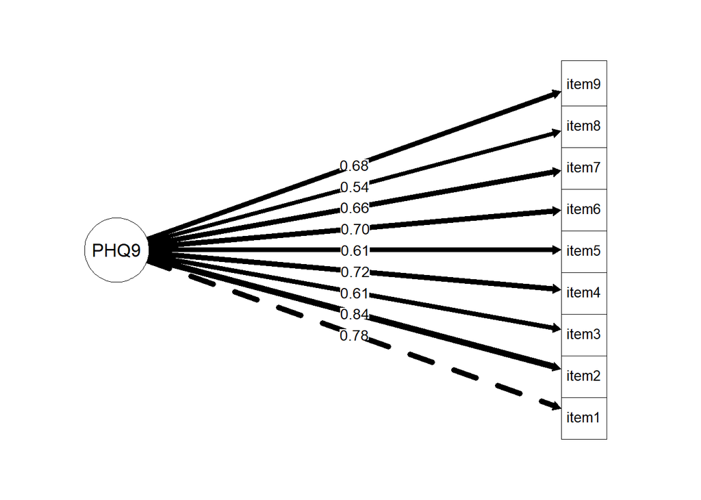

### CFA comparison

```r
# Two-factor correlated model
cfa_model_phq_2f <- '
Somatic =~ item3 + item4 + item5 + item8

CognitiveAffective =~ item1 + item2 + item6 + item7 + item9

Somatic ~~ CognitiveAffective
'

fit_phq_2f <- cfa(
  cfa_model_phq_2f,
  data = data_efa_phq,
  estimator = "WLSMV",
  ordered = items_phq
)

# Model summary
summary(
  fit_phq_2f,
  fit.measures = TRUE,
  standardized = TRUE,
  rsquare = TRUE
)
```

```
## lavaan 0.6-20 ended normally after 21 iterations
##
##   Estimator                                       DWLS
##   Optimization method                           NLMINB
##   Number of model parameters                        37
##
##   Number of observations                          2731
##
## Model Test User Model:
##                                               Standard      Scaled
##   Test Statistic                               368.920     637.500
##   Degrees of freedom                                26          26
##   P-value (Chi-square)                           0.000       0.000
##   Scaling correction factor                                  0.580
##   Shift parameter                                            1.862
##     simple second-order correction
##
## Model Test Baseline Model:
##
##   Test statistic                             28325.910   17038.035
##   Degrees of freedom                                36          36
##   P-value                                        0.000       0.000
##   Scaling correction factor                                  1.664
##
## User Model versus Baseline Model:
##
##   Comparative Fit Index (CFI)                    0.988       0.964
##   Tucker-Lewis Index (TLI)                       0.983       0.950
##
##   Robust Comparative Fit Index (CFI)                         0.915
##   Robust Tucker-Lewis Index (TLI)                            0.883
##
## Root Mean Square Error of Approximation:
##
##   RMSEA                                          0.070       0.093
##   90 Percent confidence interval - lower         0.063       0.087
##   90 Percent confidence interval - upper         0.076       0.099
##   P-value H_0: RMSEA <= 0.050                    0.000       0.000
##   P-value H_0: RMSEA >= 0.080                    0.003       1.000
##
```

[output cut: 76 more lines]

```
##    .item9             0.529                               0.529    0.529
##     Somatic           0.424    0.020   20.812    0.000    1.000    1.000
##     CognitivAffctv    0.618    0.016   38.301    0.000    1.000    1.000
##
## R-Square:
##                    Estimate
##     item3             0.424
##     item4             0.601
##     item5             0.437
##     item8             0.337
##     item1             0.618
##     item2             0.726
##     item6             0.511
##     item7             0.448
##     item9             0.471
```

```r
# Robust fit indices
fitMeasures(
  fit_phq_2f,
  c(
    "cfi.robust",
    "rmsea.robust",
    "rmsea.ci.lower.robust",
    "rmsea.ci.upper.robust",
    "srmr"
  )
)
```

```
##            cfi.robust          rmsea.robust rmsea.ci.lower.robust
##                 0.915                 0.114                 0.105
## rmsea.ci.upper.robust                  srmr
##                 0.122                 0.052
```

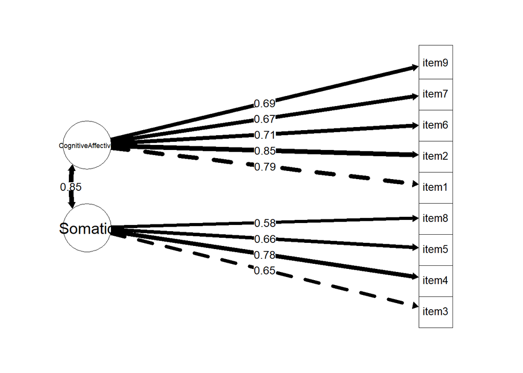

Bifactor model

```r
# Bifactor model
cfa_model_phq_bifactor <- '
# General factor
General =~ item1 + item2 + item3 + item4 + item5 +
           item6 + item7 + item8 + item9

# Specific factors
Somatic =~ item3 + item4 + item5 + item8

CognitiveAffective =~ item1 + item2 + item6 + item7 + item9

# Orthogonal factors
General ~~ 0*Somatic
General ~~ 0*CognitiveAffective
Somatic ~~ 0*CognitiveAffective
'

fit_phq_bifactor <- cfa(
  cfa_model_phq_bifactor,
  data = data_efa_phq,
  estimator = "WLSMV",
  ordered = items_phq,
  std.lv = TRUE
)

# Model summary
summary(
  fit_phq_bifactor,
  fit.measures = TRUE,
  standardized = TRUE,
  rsquare = TRUE
)
```

```
## lavaan 0.6-20 ended normally after 39 iterations
##
##   Estimator                                       DWLS
##   Optimization method                           NLMINB
##   Number of model parameters                        45
##
##   Number of observations                          2731
##
## Model Test User Model:
##                                               Standard      Scaled
##   Test Statistic                                96.137     188.015
##   Degrees of freedom                                18          18
##   P-value (Chi-square)                           0.000       0.000
##   Scaling correction factor                                  0.514
##   Shift parameter                                            0.983
##     simple second-order correction
##
## Model Test Baseline Model:
##
##   Test statistic                             28325.910   17038.035
##   Degrees of freedom                                36          36
##   P-value                                        0.000       0.000
##   Scaling correction factor                                  1.664
##
## User Model versus Baseline Model:
##
##   Comparative Fit Index (CFI)                    0.997       0.990
##   Tucker-Lewis Index (TLI)                       0.994       0.980
##
##   Robust Comparative Fit Index (CFI)                         0.973
##   Robust Tucker-Lewis Index (TLI)                            0.946
##
## Root Mean Square Error of Approximation:
##
##   RMSEA                                          0.040       0.059
##   90 Percent confidence interval - lower         0.032       0.051
##   90 Percent confidence interval - upper         0.048       0.067
##   P-value H_0: RMSEA <= 0.050                    0.982       0.026
##   P-value H_0: RMSEA >= 0.080                    0.000       0.000
##
```

[output cut: 90 more lines]

```
##     General           1.000                               1.000    1.000
##     Somatic           1.000                               1.000    1.000
##     CognitivAffctv    1.000                               1.000    1.000
##
## R-Square:
##                    Estimate
##     item1             0.606
##     item2             0.853
##     item3             0.549
##     item4             0.605
##     item5             0.420
##     item6             0.504
##     item7             0.614
##     item8             0.335
##     item9             0.493
```

```r
# Robust fit indices
fitMeasures(
  fit_phq_bifactor,
  c(
    "cfi.robust",
    "tli.robust",
    "rmsea.robust",
    "rmsea.ci.lower.robust",
    "rmsea.ci.upper.robust",
    "srmr"
  )
)
```

```
##            cfi.robust            tli.robust          rmsea.robust
##                 0.973                 0.946                 0.077
## rmsea.ci.lower.robust rmsea.ci.upper.robust                  srmr
##                 0.067                 0.088                 0.027
```

```r
# Extract robust fit indices
indices <- c(
  "cfi.robust",
  "rmsea.robust",
  "rmsea.ci.lower.robust",
  "rmsea.ci.upper.robust",
  "srmr"
)

# Comparison table
comparison_phq <- rbind(
  Unidimensional = fitMeasures(fit_phq_1f, indices),
  Two_factor = fitMeasures(fit_phq_2f, indices),
  Bifactor = fitMeasures(fit_phq_bifactor, indices)
)

round(comparison_phq, 3)
```

```
##                cfi.robust rmsea.robust rmsea.ci.lower.robust
## Unidimensional      0.883        0.131                 0.123
## Two_factor          0.915        0.114                 0.105
## Bifactor            0.973        0.077                 0.067
##                rmsea.ci.upper.robust  srmr
## Unidimensional                 0.139 0.059
## Two_factor                     0.122 0.052
## Bifactor                       0.088 0.027
```

Supplementary bifactorial indices

```r
# 1. Extraire les saturations factorielles standardisées
L <- inspect(fit_phq_bifactor, "std")$lambda

# Vérifier la structure
print(L)
```

```
##       Generl Somatc CgntvA
## item1  0.691  0.000  0.359
## item2  0.719  0.000  0.580
## item3  0.581  0.460  0.000
## item4  0.711  0.316  0.000
## item5  0.619  0.193  0.000
## item6  0.651  0.000  0.282
## item7  0.767  0.000 -0.162
## item8  0.578 -0.030  0.000
## item9  0.593  0.000  0.377
```

```r
# 2. Extraire les variances résiduelles standardisées
theta <- diag(inspect(fit_phq_bifactor, "std")$theta)

# 3. Saturations sur les trois facteurs
g <- L[, "General"]
s <- L[, "Somatic"]
c <- L[, "CognitiveAffective"]

# 4. Explained Common Variance (ECV)
ECV <- sum(g^2) / sum(L^2)

# 5. Omega total (omega)
variance_totale_commune <- sum(colSums(L)^2)
variance_erreur <- sum(theta)

omega <- variance_totale_commune /
  (variance_totale_commune + variance_erreur)

# 6. Omega hiérarchique (omega H)
omegaH <- sum(g)^2 /
  (variance_totale_commune + variance_erreur)

# 7. Afficher les résultats
data.frame(
  Index = c("Omega total", "Omega hierarchical", "ECV"),
  Value = round(c(omega, omegaH, ECV), 3)
)
```

```
##                Index Value
## 1        Omega total 0.904
## 2 Omega hierarchical 0.834
## 3                ECV 0.787
```

## WHODAS-12

### unidimensional CFA

```r
items_who <- paste0("item", 1:12)
cfa_model <- '
WHODAS12 =~ item1 + item2 + item3 + item4 +
        item5 + item6 + item7 + item8 + item9 + item10 + item11 + item12
'
fit_who_1f <- cfa(
  cfa_model,
  data = data_efa_who,
  estimator = "WLSMV",
  ordered = items_who
)
summary(fit_who_1f, fit.measures = TRUE, standardized = TRUE, rsquare = TRUE)
```

```
## lavaan 0.6-20 ended normally after 24 iterations
##
##   Estimator                                       DWLS
##   Optimization method                           NLMINB
##   Number of model parameters                        60
##
##   Number of observations                          2731
##
## Model Test User Model:
##                                               Standard      Scaled
##   Test Statistic                              3628.805    4647.408
##   Degrees of freedom                                54          54
##   P-value (Chi-square)                           0.000       0.000
##   Scaling correction factor                                  0.783
##   Shift parameter                                           14.905
##     simple second-order correction
##
## Model Test Baseline Model:
##
##   Test statistic                             71770.918   32554.405
##   Degrees of freedom                                66          66
##   P-value                                        0.000       0.000
##   Scaling correction factor                                  2.207
##
## User Model versus Baseline Model:
##
##   Comparative Fit Index (CFI)                    0.950       0.859
##   Tucker-Lewis Index (TLI)                       0.939       0.827
##
##   Robust Comparative Fit Index (CFI)                         0.720
##   Robust Tucker-Lewis Index (TLI)                            0.658
##
## Root Mean Square Error of Approximation:
##
##   RMSEA                                          0.156       0.177
##   90 Percent confidence interval - lower         0.151       0.172
##   90 Percent confidence interval - upper         0.160       0.181
##   P-value H_0: RMSEA <= 0.050                    0.000       0.000
##   P-value H_0: RMSEA >= 0.080                    1.000       1.000
##
```

[output cut: 99 more lines]

```
##
## R-Square:
##                    Estimate
##     item1             0.489
##     item2             0.592
##     item3             0.525
##     item4             0.563
##     item5             0.408
##     item6             0.416
##     item7             0.522
##     item8             0.678
##     item9             0.697
##     item10            0.402
##     item11            0.357
##     item12            0.420
```

```r
# Robust fit indices
fitMeasures(
  fit_who_1f,
  c(
    "cfi.robust",
    "rmsea.robust",
    "rmsea.ci.lower.robust",
    "rmsea.ci.upper.robust",
    "srmr"
  )
)
```

```
##            cfi.robust          rmsea.robust rmsea.ci.lower.robust
##                 0.720                 0.190                 0.184
## rmsea.ci.upper.robust                  srmr
##                 0.196                 0.107
```

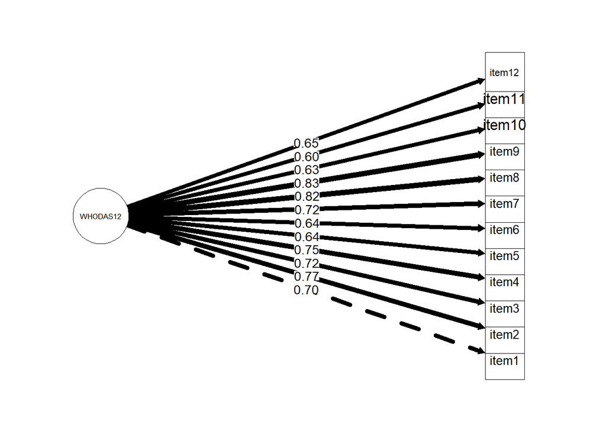

### CFA comparison

```r
model_who_6f <- '
  Cognition =~ item3 + item6
  Mobility =~ item1 + item7
  SelfCare =~ item8 + item9
  GettingAlong =~ item10 + item11
  LifeActivities =~ item2 + item12
  Participation =~ item4 + item5
'

fit_who_6f <- cfa(
  model_who_6f,
  data = data_efa_who,
  estimator = "WLSMV",
  ordered = items_who
)
summary(fit_who_6f, fit.measures = TRUE, standardized = TRUE)
```

```
## lavaan 0.6-20 ended normally after 33 iterations
##
##   Estimator                                       DWLS
##   Optimization method                           NLMINB
##   Number of model parameters                        75
##
##   Number of observations                          2731
##
## Model Test User Model:
##                                               Standard      Scaled
##   Test Statistic                               213.985     432.362
##   Degrees of freedom                                39          39
##   P-value (Chi-square)                           0.000       0.000
##   Scaling correction factor                                  0.502
##   Shift parameter                                            6.390
##     simple second-order correction
##
## Model Test Baseline Model:
##
##   Test statistic                             71770.918   32554.405
##   Degrees of freedom                                66          66
##   P-value                                        0.000       0.000
##   Scaling correction factor                                  2.207
##
## User Model versus Baseline Model:
##
##   Comparative Fit Index (CFI)                    0.998       0.988
##   Tucker-Lewis Index (TLI)                       0.996       0.980
##
##   Robust Comparative Fit Index (CFI)                         0.979
##   Robust Tucker-Lewis Index (TLI)                            0.964
##
## Root Mean Square Error of Approximation:
##
##   RMSEA                                          0.041       0.061
##   90 Percent confidence interval - lower         0.035       0.056
##   90 Percent confidence interval - upper         0.046       0.066
##   P-value H_0: RMSEA <= 0.050                    0.998       0.000
##   P-value H_0: RMSEA >= 0.080                    0.000       0.000
##
```

[output cut: 117 more lines]

```
##    .item7             0.201                               0.201    0.201
##    .item8             0.167                               0.167    0.167
##    .item9             0.137                               0.137    0.137
##    .item10            0.398                               0.398    0.398
##    .item11            0.474                               0.474    0.474
##    .item2             0.328                               0.328    0.328
##    .item12            0.530                               0.530    0.530
##    .item4             0.404                               0.404    0.404
##    .item5             0.554                               0.554    0.554
##     Cognition         0.630    0.019   33.711    0.000    1.000    1.000
##     Mobility          0.724    0.018   41.273    0.000    1.000    1.000
##     SelfCare          0.833    0.017   50.168    0.000    1.000    1.000
##     GettingAlong      0.602    0.019   31.538    0.000    1.000    1.000
##     LifeActivities    0.672    0.017   39.934    0.000    1.000    1.000
##     Participation     0.596    0.018   32.349    0.000    1.000    1.000
```

```r
# Robust fit indices
fitMeasures(
  fit_who_6f,
  c(
    "cfi.robust",
    "rmsea.robust",
    "rmsea.ci.lower.robust",
    "rmsea.ci.upper.robust",
    "srmr"
  )
)
```

```
##            cfi.robust          rmsea.robust rmsea.ci.lower.robust
##                 0.979                 0.062                 0.055
## rmsea.ci.upper.robust                  srmr
##                 0.069                 0.028
```

Additional informations

```r
cov_lv <- lavInspect(fit_who_6f, "cov.lv")

round(cov_lv, 3)
```

```
##                Cogntn Moblty SelfCr GttngA LfActv Prtcpt
## Cognition       0.630
## Mobility        0.404  0.724
## SelfCare        0.461  0.514  0.833
## GettingAlong    0.510  0.210  0.360  0.602
## LifeActivities  0.606  0.474  0.527  0.504  0.672
## Participation   0.592  0.414  0.442  0.571  0.620  0.596
```

```r
eigen(cov_lv, symmetric = TRUE)$values
```

```
## [1]  3.10025324  0.58338753  0.27831919  0.08172026  0.04017253 -0.02646589
```

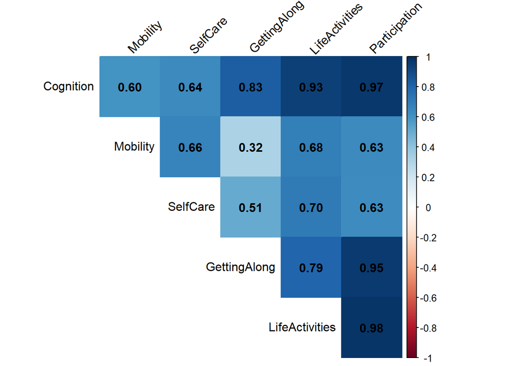

```r
x <- round(lavInspect(fit_who_6f, "cor.lv"), 3)

# Heatmap
corrplot(x,
         method = "color",
         type = "upper",
         addCoef.col = "black",
         tl.col = "black",
         tl.srt = 45,
         diag = FALSE)
```

```r
model_who_2nd <- '
  # Facteurs de premier ordre
  Cognition =~ item3 + item6
  Mobility =~ item1 + item7
  SelfCare =~ item8 + item9
  GettingAlong =~ item10 + item11
  LifeActivities =~ item2 + item12
  Participation =~ item4 + item5

  # Facteur de second ordre
  GeneralFunctioning =~ Cognition + Mobility +
                        SelfCare + GettingAlong +
                        LifeActivities + Participation
'

fit_who_2nd <- cfa(
  model_who_2nd,
  data = data_efa_who,
  estimator = "WLSMV",
  ordered = items_who
)
summary(fit_who_2nd, fit.measures = TRUE, standardized = TRUE)
```

```
## lavaan 0.6-20 ended normally after 26 iterations
##
##   Estimator                                       DWLS
##   Optimization method                           NLMINB
##   Number of model parameters                        66
##
##   Number of observations                          2731
##
## Model Test User Model:
##                                               Standard      Scaled
##   Test Statistic                               947.171    1456.371
##   Degrees of freedom                                48          48
##   P-value (Chi-square)                           0.000       0.000
##   Scaling correction factor                                  0.655
##   Shift parameter                                           10.915
##     simple second-order correction
##
## Model Test Baseline Model:
##
##   Test statistic                             71770.918   32554.405
##   Degrees of freedom                                66          66
##   P-value                                        0.000       0.000
##   Scaling correction factor                                  2.207
##
## User Model versus Baseline Model:
##
##   Comparative Fit Index (CFI)                    0.987       0.957
##   Tucker-Lewis Index (TLI)                       0.983       0.940
##
##   Robust Comparative Fit Index (CFI)                         0.938
##   Robust Tucker-Lewis Index (TLI)                            0.914
##
## Root Mean Square Error of Approximation:
##
##   RMSEA                                          0.083       0.104
##   90 Percent confidence interval - lower         0.078       0.099
##   90 Percent confidence interval - upper         0.087       0.108
##   P-value H_0: RMSEA <= 0.050                    0.000       0.000
##   P-value H_0: RMSEA >= 0.080                    0.848       1.000
##
```

[output cut: 102 more lines]

```
##    .item8             0.168                               0.168    0.168
##    .item9             0.136                               0.136    0.136
##    .item10            0.398                               0.398    0.398
##    .item11            0.474                               0.474    0.474
##    .item2             0.328                               0.328    0.328
##    .item12            0.530                               0.530    0.530
##    .item4             0.399                               0.399    0.399
##    .item5             0.558                               0.558    0.558
##    .Cognition         0.070    0.015    4.749    0.000    0.111    0.111
##    .Mobility          0.392    0.016   24.589    0.000    0.544    0.544
##    .SelfCare          0.397    0.018   22.487    0.000    0.478    0.478
##    .GettingAlong      0.200    0.016   12.262    0.000    0.332    0.332
##    .LifeActivities    0.028    0.013    2.083    0.037    0.042    0.042
##    .Participation    -0.016    0.014   -1.103    0.270   -0.027   -0.027
##     GeneralFnctnng    0.561    0.016   35.139    0.000    1.000    1.000
```

```r
# Robust fit indices
fitMeasures(
  fit_who_2nd,
  c(
    "cfi.robust",
    "rmsea.robust",
    "rmsea.ci.lower.robust",
    "rmsea.ci.upper.robust",
    "srmr"
  )
)
```

```
##            cfi.robust          rmsea.robust rmsea.ci.lower.robust
##                 0.938                 0.095                 0.089
## rmsea.ci.upper.robust                  srmr
##                 0.101                 0.061
```

## SSS-S

### unidimensional CFA

```r
items_sss <- paste0("item", 1:9)
cfa_model <- '
SSS =~ item1 + item2 + item3 + item4 +
        item5 + item6 + item7 + item8 + item9
'
fit_sss_1f <- cfa(
  cfa_model,
  data = data_efa_sss,
  estimator = "WLSMV",
  ordered = items_sss
)
summary(fit_sss_1f, fit.measures = TRUE, standardized = TRUE, rsquare = TRUE)
```

```
## lavaan 0.6-20 ended normally after 22 iterations
##
##   Estimator                                       DWLS
##   Optimization method                           NLMINB
##   Number of model parameters                        45
##
##   Number of observations                          2731
##
## Model Test User Model:
##                                               Standard      Scaled
##   Test Statistic                              1291.510    2238.334
##   Degrees of freedom                                27          27
##   P-value (Chi-square)                           0.000       0.000
##   Scaling correction factor                                  0.578
##   Shift parameter                                            4.895
##     simple second-order correction
##
## Model Test Baseline Model:
##
##   Test statistic                             64782.274   30473.388
##   Degrees of freedom                                36          36
##   P-value                                        0.000       0.000
##   Scaling correction factor                                  2.127
##
## User Model versus Baseline Model:
##
##   Comparative Fit Index (CFI)                    0.980       0.927
##   Tucker-Lewis Index (TLI)                       0.974       0.903
##
##   Robust Comparative Fit Index (CFI)                         0.836
##   Robust Tucker-Lewis Index (TLI)                            0.781
##
## Root Mean Square Error of Approximation:
##
##   RMSEA                                          0.131       0.173
##   90 Percent confidence interval - lower         0.125       0.167
##   90 Percent confidence interval - upper         0.137       0.179
##   P-value H_0: RMSEA <= 0.050                    0.000       0.000
##   P-value H_0: RMSEA >= 0.080                    1.000       1.000
##
```

[output cut: 78 more lines]

```
##    .item8             0.422                               0.422    0.422
##    .item9             0.344                               0.344    0.344
##     SSS               0.375    0.015   25.146    0.000    1.000    1.000
##
## R-Square:
##                    Estimate
##     item1             0.375
##     item2             0.447
##     item3             0.611
##     item4             0.597
##     item5             0.622
##     item6             0.678
##     item7             0.400
##     item8             0.578
##     item9             0.656
```

```r
# Robust fit indices
fitMeasures(
  fit_sss_1f,
  c(
    "cfi.robust",
    "rmsea.robust",
    "rmsea.ci.lower.robust",
    "rmsea.ci.upper.robust",
    "srmr"
  )
)
```

```
##            cfi.robust          rmsea.robust rmsea.ci.lower.robust
##                 0.836                 0.179                 0.172
## rmsea.ci.upper.robust                  srmr
##                 0.186                 0.073
```

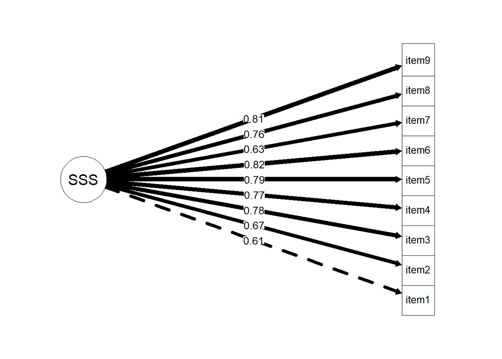

### CFA comparison

```r
# Three-factor correlated model
model_sss_3f <- '
  Cognitive =~ item1 + item2 + item3
  Affective =~ item4 + item5 + item6
  Behavioural =~ item7 + item8 + item9
'

fit_sss_3f <- cfa(
  model_sss_3f,
  data = data_efa_sss,
  estimator = "WLSMV",
  ordered = items_sss
)
summary(fit_sss_3f, fit.measures = TRUE, standardized = TRUE, rsquare = TRUE)
```

```
## lavaan 0.6-20 ended normally after 28 iterations
##
##   Estimator                                       DWLS
##   Optimization method                           NLMINB
##   Number of model parameters                        48
##
##   Number of observations                          2731
##
## Model Test User Model:
##                                               Standard      Scaled
##   Test Statistic                              1254.764    2195.475
##   Degrees of freedom                                24          24
##   P-value (Chi-square)                           0.000       0.000
##   Scaling correction factor                                  0.573
##   Shift parameter                                            4.258
##     simple second-order correction
##
## Model Test Baseline Model:
##
##   Test statistic                             64782.274   30473.388
##   Degrees of freedom                                36          36
##   P-value                                        0.000       0.000
##   Scaling correction factor                                  2.127
##
## User Model versus Baseline Model:
##
##   Comparative Fit Index (CFI)                    0.981       0.929
##   Tucker-Lewis Index (TLI)                       0.971       0.893
##
##   Robust Comparative Fit Index (CFI)                         0.834
##   Robust Tucker-Lewis Index (TLI)                            0.752
##
## Root Mean Square Error of Approximation:
##
##   RMSEA                                          0.137       0.182
##   90 Percent confidence interval - lower         0.131       0.176
##   90 Percent confidence interval - upper         0.144       0.189
##   P-value H_0: RMSEA <= 0.050                    0.000       0.000
##   P-value H_0: RMSEA >= 0.080                    1.000       1.000
##
```

[output cut: 90 more lines]

```
##     Cognitive         0.389    0.015   25.087    0.000    1.000    1.000
##     Affective         0.578    0.013   43.131    0.000    1.000    1.000
##     Behavioural       0.396    0.015   27.289    0.000    1.000    1.000
##
## R-Square:
##                    Estimate
##     item1             0.389
##     item2             0.464
##     item3             0.640
##     item4             0.578
##     item5             0.601
##     item6             0.645
##     item7             0.396
##     item8             0.571
##     item9             0.646
```

```r
# Robust fit indices
fitMeasures(
  fit_sss_3f,
  c(
    "cfi.robust",
    "rmsea.robust",
    "rmsea.ci.lower.robust",
    "rmsea.ci.upper.robust",
    "srmr"
  )
)
```

```
##            cfi.robust          rmsea.robust rmsea.ci.lower.robust
##                 0.834                 0.191                 0.184
## rmsea.ci.upper.robust                  srmr
##                 0.198                 0.072
```

```r
# Correlations between latent factors
round(lavInspect(fit_sss_3f, "cor.lv"), 3)
```

```
##             Cogntv Affctv Behvrl
## Cognitive    1.000
## Affective    1.004  1.000
## Behavioural  0.958  1.049  1.000
```

```r
# Check for negative residual variances
lavInspect(fit_sss_3f, "theta")
```

```
##       item1 item2 item3 item4 item5 item6 item7 item8 item9
## item1 0.611
## item2 0.000 0.536
## item3 0.000 0.000 0.360
## item4 0.000 0.000 0.000 0.422
## item5 0.000 0.000 0.000 0.000 0.399
## item6 0.000 0.000 0.000 0.000 0.000 0.355
## item7 0.000 0.000 0.000 0.000 0.000 0.000 0.604
## item8 0.000 0.000 0.000 0.000 0.000 0.000 0.000 0.429
## item9 0.000 0.000 0.000 0.000 0.000 0.000 0.000 0.000 0.354
```

```r
# Check eigenvalues of the latent covariance matrix
eigen(lavInspect(fit_sss_3f, "cov.lv"), symmetric = TRUE)$values
```

```
## [1]  1.37191678  0.01923548 -0.02793289
```

Bifactor model

```r
cfa_model_sss_bifactor <- '
# General factor
General =~ item1 + item2 + item3 + item4 + item5 +
           item6 + item7 + item8 + item9

# Specific factors
  Cognitive =~ item1 + item2 + item3
  Affective =~ item4 + item5 + item6
  Behavioural =~ item7 + item8 + item9

 # Orthogonality between general and specific factors
  General ~~ 0*Cognitive
  General ~~ 0*Affective
  General ~~ 0*Behavioural

  # Orthogonality between specific factors
  Cognitive ~~ 0*Affective
  Cognitive ~~ 0*Behavioural
  Affective ~~ 0*Behavioural
'

fit_sss_bifactor <- cfa(
  cfa_model_sss_bifactor,
  data = data_efa_sss,
  estimator = "WLSMV",
  ordered = items_sss,
  std.lv = TRUE
)
# Model summary
summary(
  fit_sss_bifactor,
  fit.measures = TRUE,
  standardized = TRUE,
  rsquare = TRUE
)
```

```
## lavaan 0.6-20 ended normally after 568 iterations
##
##   Estimator                                       DWLS
##   Optimization method                           NLMINB
##   Number of model parameters                        54
##
##   Number of observations                          2731
##
## Model Test User Model:
##                                               Standard      Scaled
##   Test Statistic                              1000.363          NA
##   Degrees of freedom                                18          18
##   P-value (Chi-square)                           0.000          NA
##   Scaling correction factor                                     NA
##   Shift parameter                                               NA
##
##
## Model Test Baseline Model:
##
##   Test statistic                             64782.274   30473.388
##   Degrees of freedom                                36          36
##   P-value                                        0.000       0.000
##   Scaling correction factor                                  2.127
##
## User Model versus Baseline Model:
##
##   Comparative Fit Index (CFI)                    0.985          NA
##   Tucker-Lewis Index (TLI)                       0.970          NA
##
##   Robust Comparative Fit Index (CFI)                            NA
##   Robust Tucker-Lewis Index (TLI)                               NA
##
## Root Mean Square Error of Approximation:
##
##   RMSEA                                          0.141          NA
##   90 Percent confidence interval - lower         0.134          NA
##   90 Percent confidence interval - upper         0.149          NA
##   P-value H_0: RMSEA <= 0.050                    0.000          NA
##   P-value H_0: RMSEA >= 0.080                    1.000          NA
##
```

[output cut: 105 more lines]

```
##     Cognitive           1.000                                 1.000      1.000
##     Affective           1.000                                 1.000      1.000
##     Behavioural         1.000                                 1.000      1.000
##
## R-Square:
##                    Estimate
##     item1                  NA
##     item2               0.436
##     item3               0.590
##     item4               0.672
##     item5               0.710
##     item6                  NA
##     item7               0.380
##     item8                  NA
##     item9               0.656
```

```r
# Robust fit indices
fitMeasures(
  fit_sss_bifactor,
  c(
    "cfi.robust",
    "rmsea.robust",
    "rmsea.ci.lower.robust",
    "rmsea.ci.upper.robust",
    "srmr"
  )
)
```

```
##            cfi.robust          rmsea.robust rmsea.ci.lower.robust
##                    NA                    NA                    NA
## rmsea.ci.upper.robust                  srmr
##                    NA                 0.067
```

### Exploration of the 14 items structure

```r
# si tu veux je ne souhaite pas rep = NA -> peut etre en sensibility analysis
#dat_stigma <- dat %>%
 # mutate(
   # Stigma_ext_1 = na_if(Stigma_ext_1, "Je ne préfère pas répondre à cette question"),
    #Stigma_ext_2 = na_if(Stigma_ext_2, "Je ne préfère pas répondre à cette question"),
    #Stigma_ext_3 = na_if(Stigma_ext_3, "Je ne préfère pas répondre à cette question"),
    #Stigma_ext_4 = na_if(Stigma_ext_4, "Je ne préfère pas répondre à cette question"),
    #Stigma_ext_5 = na_if(Stigma_ext_5, "Je ne préfère pas répondre à cette question")
 # )
# si tu veux je ne souhaite pas rep = 0 et non NA alors met dat_stigma <- dat %>%
dat_stigma <- dat %>%
  mutate(
    Stigma_ext_1 = as.numeric(Stigma_ext_1 == "Oui"),
    Stigma_ext_2 = as.numeric(Stigma_ext_2 == "Oui"),
    Stigma_ext_3 = as.numeric(Stigma_ext_3 == "Oui"),
    Stigma_ext_4 = as.numeric(Stigma_ext_4 == "Non"),
    Stigma_ext_5 = as.numeric(Stigma_ext_5 == "Oui")
  )

# Sélectionner les 14 items
items_all <- dat_stigma %>%
  dplyr::select(
    stigma_auto_1:stigma_auto_9,
    Stigma_ext_1:Stigma_ext_5
  )

# Vérifier les distributions et les valeurs manquantes
summary(items_all)
```

```
##  stigma_auto_1   stigma_auto_2   stigma_auto_3   stigma_auto_4   stigma_auto_5
##  Min.   :1.000   Min.   :1.000   Min.   :1.000   Min.   :1.000   Min.   :1.00
##  1st Qu.:2.000   1st Qu.:3.000   1st Qu.:1.000   1st Qu.:2.000   1st Qu.:3.00
##  Median :3.000   Median :4.000   Median :2.000   Median :3.000   Median :4.00
##  Mean   :2.973   Mean   :3.435   Mean   :2.457   Mean   :3.021   Mean   :3.59
##  3rd Qu.:4.000   3rd Qu.:4.000   3rd Qu.:3.000   3rd Qu.:4.000   3rd Qu.:4.00
##  Max.   :5.000   Max.   :5.000   Max.   :5.000   Max.   :5.000   Max.   :5.00
##  stigma_auto_6   stigma_auto_7  stigma_auto_8   stigma_auto_9   Stigma_ext_1
##  Min.   :1.000   Min.   :1.00   Min.   :1.000   Min.   :1.00   Min.   :0.0000
##  1st Qu.:2.000   1st Qu.:2.00   1st Qu.:2.000   1st Qu.:2.00   1st Qu.:0.0000
##  Median :3.000   Median :3.00   Median :3.000   Median :3.00   Median :0.0000
##  Mean   :3.108   Mean   :2.97   Mean   :2.749   Mean   :2.72   Mean   :0.2285
##  3rd Qu.:4.000   3rd Qu.:4.00   3rd Qu.:4.000   3rd Qu.:4.00   3rd Qu.:0.0000
##  Max.   :5.000   Max.   :5.00   Max.   :5.000   Max.   :5.00   Max.   :1.0000
##   Stigma_ext_2     Stigma_ext_3     Stigma_ext_4     Stigma_ext_5
##  Min.   :0.0000   Min.   :0.0000   Min.   :0.0000   Min.   :0.0000
##  1st Qu.:0.0000   1st Qu.:0.0000   1st Qu.:0.0000   1st Qu.:0.0000
##  Median :1.0000   Median :0.0000   Median :0.0000   Median :0.0000
##  Mean   :0.5093   Mean   :0.2237   Mean   :0.2739   Mean   :0.1377
##  3rd Qu.:1.0000   3rd Qu.:0.0000   3rd Qu.:1.0000   3rd Qu.:0.0000
##  Max.   :1.0000   Max.   :1.0000   Max.   :1.0000   Max.   :1.0000
```

```r
# Matrice de corrélations polychoriques
cor_all <- psych::polychoric(
  items_all,
  correct = 0.5
)$rho
round(cor_all, 3)
```

```
##               stigma_auto_1 stigma_auto_2 stigma_auto_3 stigma_auto_4
## stigma_auto_1         1.000         0.438         0.525         0.602
## stigma_auto_2         0.438         1.000         0.505         0.488
## stigma_auto_3         0.525         0.505         1.000         0.612
## stigma_auto_4         0.602         0.488         0.612         1.000
## stigma_auto_5         0.484         0.629         0.540         0.690
## stigma_auto_6         0.352         0.453         0.649         0.526
## stigma_auto_7         0.295         0.427         0.486         0.450
## stigma_auto_8         0.500         0.547         0.594         0.599
## stigma_auto_9         0.345         0.435         0.653         0.466
## Stigma_ext_1          0.052         0.252         0.161         0.136
## Stigma_ext_2          0.587         0.371         0.392         0.512
## Stigma_ext_3          0.021         0.182         0.077         0.083
## Stigma_ext_4          0.154         0.288         0.264         0.210
## Stigma_ext_5          0.060         0.284         0.210         0.167
##               stigma_auto_5 stigma_auto_6 stigma_auto_7 stigma_auto_8
## stigma_auto_1         0.484         0.352         0.295         0.500
## stigma_auto_2         0.629         0.453         0.427         0.547
## stigma_auto_3         0.540         0.649         0.486         0.594
## stigma_auto_4         0.690         0.526         0.450         0.599
## stigma_auto_5         1.000         0.530         0.504         0.636
## stigma_auto_6         0.530         1.000         0.532         0.532
## stigma_auto_7         0.504         0.532         1.000         0.535
## stigma_auto_8         0.636         0.532         0.535         1.000
## stigma_auto_9         0.466         0.788         0.517         0.552
## Stigma_ext_1          0.159         0.152         0.164         0.203
## Stigma_ext_2          0.436         0.325         0.272         0.399
## Stigma_ext_3          0.091         0.082         0.090         0.140
## Stigma_ext_4          0.264         0.247         0.250         0.334
## Stigma_ext_5          0.201         0.279         0.201         0.264
##               stigma_auto_9 Stigma_ext_1 Stigma_ext_2 Stigma_ext_3 Stigma_ext_4
## stigma_auto_1         0.345        0.052        0.587        0.021        0.154
## stigma_auto_2         0.435        0.252        0.371        0.182        0.288
## stigma_auto_3         0.653        0.161        0.392        0.077        0.264
## stigma_auto_4         0.466        0.136        0.512        0.083        0.210
## stigma_auto_5         0.466        0.159        0.436        0.091        0.264
## stigma_auto_6         0.788        0.152        0.325        0.082        0.247
## stigma_auto_7         0.517        0.164        0.272        0.090        0.250
## stigma_auto_8         0.552        0.203        0.399        0.140        0.334
## stigma_auto_9         1.000        0.158        0.312        0.083        0.235
## Stigma_ext_1          0.158        1.000        0.291        0.458        0.450
## Stigma_ext_2          0.312        0.291        1.000        0.177        0.266
## Stigma_ext_3          0.083        0.458        0.177        1.000        0.398
## Stigma_ext_4          0.235        0.450        0.266        0.398        1.000
## Stigma_ext_5          0.235        0.562        0.216        0.477        0.480
##               Stigma_ext_5
## stigma_auto_1        0.060
## stigma_auto_2        0.284
## stigma_auto_3        0.210
## stigma_auto_4        0.167
## stigma_auto_5        0.201
## stigma_auto_6        0.279
## stigma_auto_7        0.201
## stigma_auto_8        0.264
## stigma_auto_9        0.235
## Stigma_ext_1         0.562
## Stigma_ext_2         0.216
## Stigma_ext_3         0.477
## Stigma_ext_4         0.480
## Stigma_ext_5         1.000
```

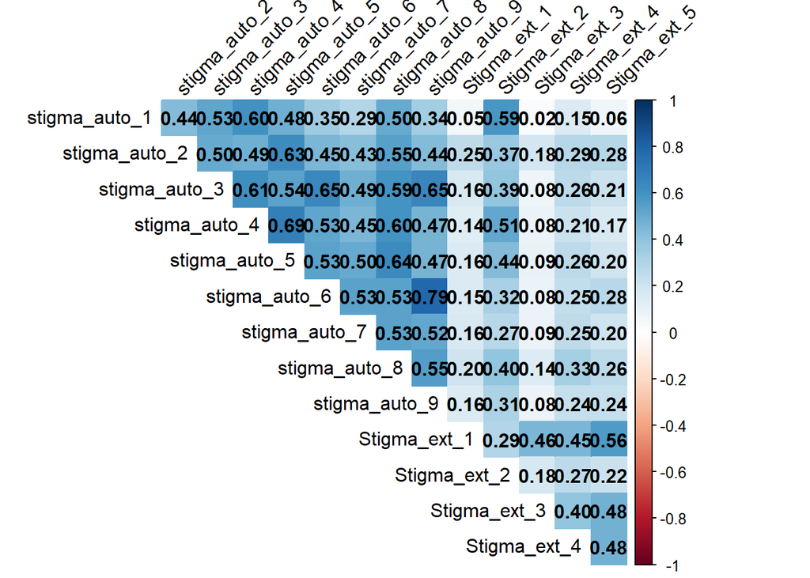

```r
# Visualisation
library(corrplot)

corrplot(
  cor_all,
  method = "color",
  type = "upper",
  addCoef.col = "black",
  tl.col = "black",
  tl.srt = 45,
  diag = FALSE
)
```

```r
# Test de Kaiser-Meyer-Olkin
KMO(cor_all)
```

```
## Kaiser-Meyer-Olkin factor adequacy
## Call: KMO(r = cor_all)
## Overall MSA =  0.89
## MSA for each item =
## stigma_auto_1 stigma_auto_2 stigma_auto_3 stigma_auto_4 stigma_auto_5
##          0.86          0.93          0.94          0.91          0.89
## stigma_auto_6 stigma_auto_7 stigma_auto_8 stigma_auto_9  Stigma_ext_1
##          0.86          0.96          0.94          0.86          0.80
##  Stigma_ext_2  Stigma_ext_3  Stigma_ext_4  Stigma_ext_5
##          0.87          0.84          0.91          0.83
```

```r
# Test de sphéricité de Bartlett
cortest.bartlett(
  cor_all,
  n = nrow(items_all)
)
```

```
## $chisq
## [1] 19602.41
##
## $p.value
## [1] 0
##
## $df
## [1] 91
```

```r
# Valeurs propres de la matrice de corrélations
eigenvalues <- eigen(cor_all, symmetric = TRUE)$values

round(eigenvalues, 3)
```

```
##  [1] 5.946 2.101 1.142 0.722 0.591 0.561 0.546 0.460 0.424 0.415 0.370 0.288
## [13] 0.239 0.195
```

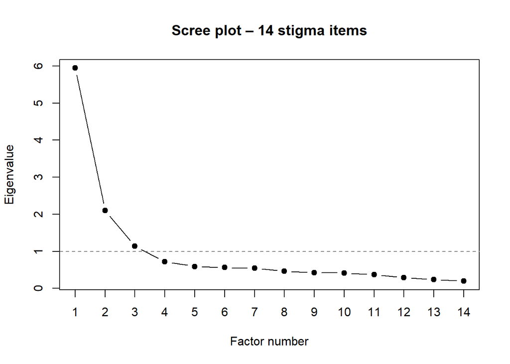

```r
# Scree plot
plot(
  eigenvalues,
  type = "b",
  pch = 19,
  xlab = "Factor number",
  ylab = "Eigenvalue",
  main = "Scree plot – 14 stigma items",
  xaxt = "n"
)

axis(1, at = 1:length(eigenvalues))
abline(h = 1, lty = 2, col = "grey50")
```

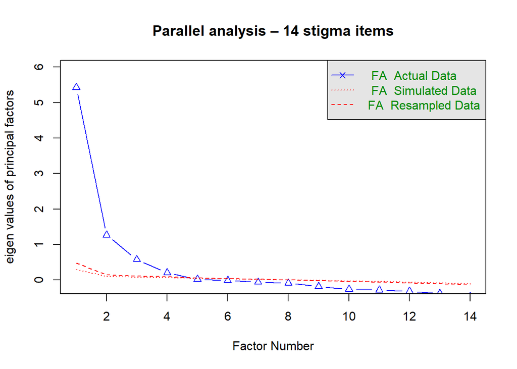

```
## Parallel analysis suggests that the number of factors =  4  and the number of components =  NA
```

```r
set.seed(123)

fa.parallel(
  items_all,
  fa = "fa",
  cor = "poly",
  fm = "minres",
  n.iter = 100,
  main = "Parallel analysis – 14 stigma items"
)
```

### Avec lavaan -> comparaison des 4 facteurs

```r
items_all <- dat_stigma %>%
  dplyr::select(
    stigma_auto_1:stigma_auto_9,
    Stigma_ext_1:Stigma_ext_5
  )
efa_stigma <- lavaan::efa(
  data = items_all,
  nfactors = 1:4,
  ordered = TRUE,
  estimator = "WLSMV",
  rotation = "geomin"
)


# Résultats détaillés des quatre solutions
summary(efa_stigma, nd = 3)
```

```
##
##   Estimator                                       DWLS
##   Rotation method                       GEOMIN OBLIQUE
##   Geomin epsilon                                 0.001
##   Rotation algorithm (rstarts)                GPA (30)
##   Standardized metric                             TRUE
##   Row weights                                     None
##
##   Number of observations                          2731
##
## Overview models:
##                   chisq df pvalue   cfi rmsea
##   nfactors = 1 3981.617 77      0 0.704 0.166
##   nfactors = 2 2251.022 64      0 0.791 0.153
##   nfactors = 3  697.912 52      0 0.948 0.085
##   nfactors = 4  198.947 41      0 0.984 0.053
##
## Eigenvalues correlation matrix:
##
##     ev1     ev2     ev3     ev4     ev5     ev6     ev7     ev8     ev9    ev10
##   5.946   2.101   1.142   0.722   0.591   0.561   0.546   0.460   0.424   0.415
##    ev11    ev12    ev13    ev14
##   0.370   0.288   0.238   0.194
##
## Number of factors:  1
##
## Standardized loadings: (* = significant at 1% level)
##
##                   f1       unique.var   communalities
## stigma_auto_1  0.627*           0.607           0.393
## stigma_auto_2  0.673*           0.547           0.453
## stigma_auto_3  0.777*           0.396           0.604
## stigma_auto_4  0.773*           0.403           0.597
## stigma_auto_5  0.785*           0.384           0.616
## stigma_auto_6  0.817*           0.332           0.668
## stigma_auto_7  0.629*           0.605           0.395
## stigma_auto_8  0.761*           0.421           0.579
## stigma_auto_9  0.803*           0.355           0.645
## Stigma_ext_1       .*           0.918           0.082
## Stigma_ext_2   0.570*           0.675           0.325
```

[output cut: 93 more lines]

```
## Stigma_ext_5                       .   0.731*           0.414           0.586
##
##                               f2    f4    f3    f1 total
## Sum of sq (obliq) loadings 2.638 2.054 2.042 1.756 8.490
## Proportion of total        0.311 0.242 0.241 0.207 1.000
## Proportion var             0.188 0.147 0.146 0.125 0.606
## Cumulative var             0.188 0.335 0.481 0.606 0.606
##
## Factor correlations: (* = significant at 1% level)
##
##        f1      f2      f3      f4
## f1  1.000
## f2  0.621*  1.000
## f3  0.410*  0.692*  1.000
## f4  0.133   0.302*  0.278*  1.000
```

### CFA comparaison 1 ou 2 facteurs corrélés

```r
# -------------------------
# Modèle à 1 facteur
# -------------------------
items_all <- c(
  "stigma_auto_1",
  "stigma_auto_2",
  "stigma_auto_3",
  "stigma_auto_4",
  "stigma_auto_5",
  "stigma_auto_6",
  "stigma_auto_7",
  "stigma_auto_8",
  "stigma_auto_9",
  "Stigma_ext_1",
  "Stigma_ext_2",
  "Stigma_ext_3",
  "Stigma_ext_4",
  "Stigma_ext_5"
)
model_1f <- '
Stigma =~ stigma_auto_1 + stigma_auto_2 + stigma_auto_3 +
          stigma_auto_4 + stigma_auto_5 + stigma_auto_6 +
          stigma_auto_7 + stigma_auto_8 + stigma_auto_9 +
          Stigma_ext_1 + Stigma_ext_2 + Stigma_ext_3 +
          Stigma_ext_4 + Stigma_ext_5
'

fit_1f <- cfa(
  model_1f,
  data = dat_stigma,
  ordered = items_all,
  estimator = "WLSMV",
  std.lv = TRUE
)

# -------------------------
# Modèle à 2 facteurs corrélés
# -------------------------

model_2f <- '
SelfStigma =~ stigma_auto_1 + stigma_auto_2 + stigma_auto_3 +
             stigma_auto_4 + stigma_auto_5 + stigma_auto_6 +
             stigma_auto_7 + stigma_auto_8 + stigma_auto_9

ExternalStigma =~ Stigma_ext_1 + Stigma_ext_2 + Stigma_ext_3 +
                  Stigma_ext_4 + Stigma_ext_5
'

fit_2f <- cfa(
  model_2f,
  data = dat_stigma,
  ordered = items_all,
  estimator = "WLSMV",
  std.lv = TRUE
)

rbind(
  "1 facteur" = fitMeasures(
    fit_1f,
    c(
      "cfi.robust",
      "rmsea.robust",
      "rmsea.ci.lower.robust",
      "rmsea.ci.upper.robust",
      "srmr"
    )
  ),
  "2 facteurs" = fitMeasures(
    fit_2f,
    c(
      "cfi.robust",
      "rmsea.robust",
      "rmsea.ci.lower.robust",
      "rmsea.ci.upper.robust",
      "srmr"
    )
  )
)
```

```
##            cfi.robust rmsea.robust rmsea.ci.lower.robust rmsea.ci.upper.robust
## 1 facteur   0.7040890    0.1658338             0.1604837             0.1712455
## 2 facteurs  0.7210964    0.1620534             0.1561707             0.1680116
##                  srmr
## 1 facteur  0.11617297
## 2 facteurs 0.09698591
```

```r
lavTestLRT(fit_1f, fit_2f)
```

```
##
## Scaled Chi-Squared Difference Test (method = "satorra.2000")
##
## lavaan->lavTestLRT():
##    lavaan NOTE: The "Chisq" column contains standard test statistics, not the
##    robust test that should be reported per model. A robust difference test is
##    a function of two standard (not robust) statistics.
##
##        Df AIC BIC  Chisq Chisq diff   RMSEA Df diff Pr(>Chisq)
## fit_2f 76         2321.2
## fit_1f 77         2764.5     280.32 0.40246       1  < 2.2e-16 ***
## ---
## Signif. codes:  0 '***' 0.001 '**' 0.01 '*' 0.05 '.' 0.1 ' ' 1
```

```r
pe <- parameterEstimates(
  fit_2f,
  ci = TRUE,
  standardized = TRUE
)

pe[
  pe$lhs == "SelfStigma" &
  pe$op == "~~" &
  pe$rhs == "ExternalStigma",
  c("lhs", "rhs", "est", "ci.lower", "ci.upper", "pvalue")
]
```

```
##           lhs            rhs   est ci.lower ci.upper pvalue
## 72 SelfStigma ExternalStigma 0.576    0.534    0.618      0
```

```r
pe[
  pe$lhs == "ExternalStigma" &
  pe$op == "=~",
  c("rhs", "std.all", "ci.lower", "ci.upper", "pvalue")
]
```

```
##             rhs std.all ci.lower ci.upper pvalue
## 10 Stigma_ext_1   0.494    0.436    0.551      0
## 11 Stigma_ext_2   0.866    0.803    0.928      0
## 12 Stigma_ext_3   0.355    0.293    0.417      0
## 13 Stigma_ext_4   0.591    0.538    0.645      0
## 14 Stigma_ext_5   0.575    0.512    0.638      0
```

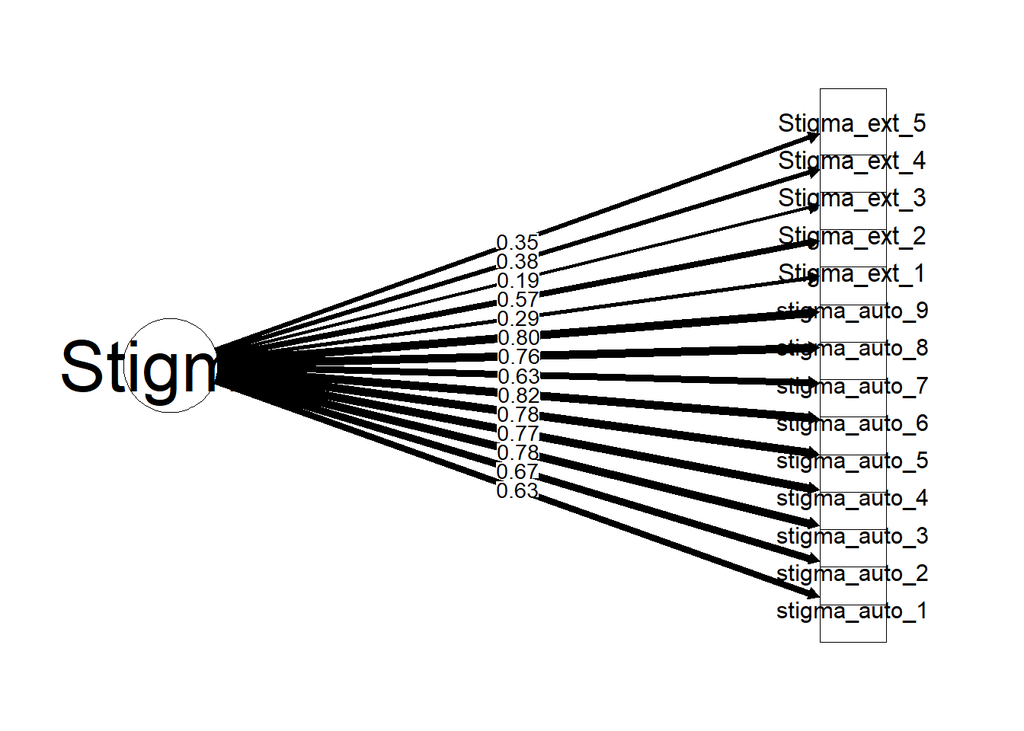

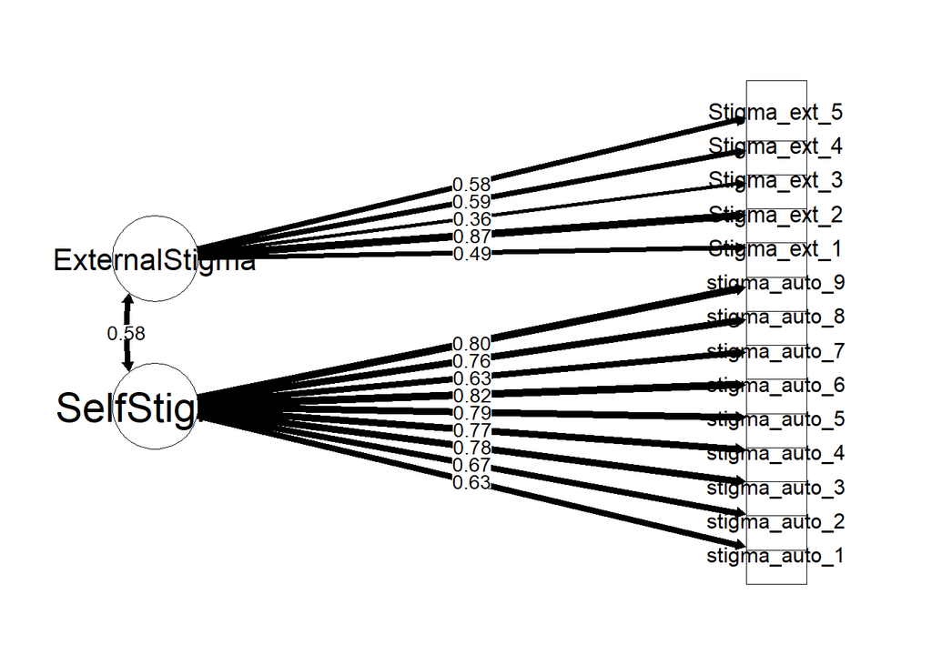

### CFA 2 facteurs issu de l’EFA

```r
items_all <- c(
  "stigma_auto_1",
  "stigma_auto_2",
  "stigma_auto_3",
  "stigma_auto_4",
  "stigma_auto_5",
  "stigma_auto_6",
  "stigma_auto_7",
  "stigma_auto_8",
  "stigma_auto_9",
  "Stigma_ext_1",
  "Stigma_ext_2",
  "Stigma_ext_3",
  "Stigma_ext_4",
  "Stigma_ext_5"
)


model_2f_efa <- '
F1 =~ stigma_auto_1 + stigma_auto_2 + stigma_auto_3 +
             stigma_auto_4 + stigma_auto_5 + stigma_auto_6 +
             stigma_auto_7 + stigma_auto_8 + stigma_auto_9 + Stigma_ext_2

F2 =~ Stigma_ext_1 + Stigma_ext_3 +
                  Stigma_ext_4 + Stigma_ext_5
'

fit_2f_efa <- cfa(
  model_2f_efa,
  data = dat_stigma,
  ordered = items_all,
  estimator = "WLSMV",
  std.lv = TRUE
)

summary(fit_2f_efa, fit.measures = TRUE, standardized = TRUE, rsquare = TRUE)
```

```
## lavaan 0.6-20 ended normally after 23 iterations
##
##   Estimator                                       DWLS
##   Optimization method                           NLMINB
##   Number of model parameters                        56
##
##   Number of observations                          2731
##
## Model Test User Model:
##                                               Standard      Scaled
##   Test Statistic                              1843.932    2500.017
##   Degrees of freedom                                76          76
##   P-value (Chi-square)                           0.000       0.000
##   Scaling correction factor                                  0.742
##   Shift parameter                                           16.262
##     simple second-order correction
##
## Model Test Baseline Model:
##
##   Test statistic                             72043.148   35089.603
##   Degrees of freedom                                91          91
##   P-value                                        0.000       0.000
##   Scaling correction factor                                  2.056
##
## User Model versus Baseline Model:
##
##   Comparative Fit Index (CFI)                    0.975       0.931
##   Tucker-Lewis Index (TLI)                       0.971       0.917
##
##   Robust Comparative Fit Index (CFI)                         0.815
##   Robust Tucker-Lewis Index (TLI)                            0.779
##
## Root Mean Square Error of Approximation:
##
##   RMSEA                                          0.092       0.108
##   90 Percent confidence interval - lower         0.089       0.104
##   90 Percent confidence interval - upper         0.096       0.112
##   P-value H_0: RMSEA <= 0.050                    0.000       0.000
##   P-value H_0: RMSEA >= 0.080                    1.000       1.000
##
```

[output cut: 105 more lines]

```
##                    Estimate
##     stigma_auto_1     0.396
##     stigma_auto_2     0.454
##     stigma_auto_3     0.606
##     stigma_auto_4     0.600
##     stigma_auto_5     0.618
##     stigma_auto_6     0.669
##     stigma_auto_7     0.396
##     stigma_auto_8     0.580
##     stigma_auto_9     0.647
##     Stigma_ext_2      0.325
##     Stigma_ext_1      0.435
##     Stigma_ext_3      0.255
##     Stigma_ext_4      0.618
##     Stigma_ext_5      0.583
```

```r
# Robust fit indices
fitMeasures(
  fit_2f_efa,
  c(
    "cfi.robust",
    "rmsea.robust",
    "rmsea.ci.lower.robust",
    "rmsea.ci.upper.robust",
    "srmr"
  )
)
```

```
##            cfi.robust          rmsea.robust rmsea.ci.lower.robust
##                 0.815                 0.132                 0.126
## rmsea.ci.upper.robust                  srmr
##                 0.138                 0.073
```

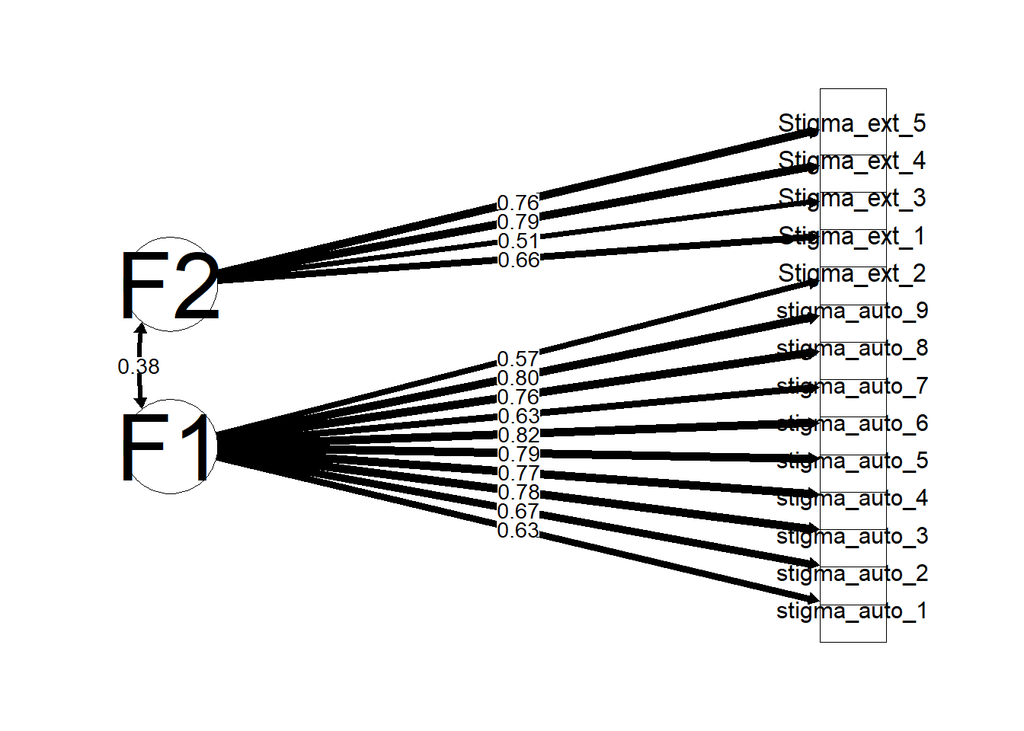

# S5. Exploratory hypothesis testing

## Convergent validity

### Simple correlation

```r
dat_bis <- dat %>%
  dplyr::select(score_PHQ9, Score_autostigma, Score_BIPQ, Score_whodas, score_GAD7)

cor_spearman2 <- cor(dat_bis$Score_BIPQ, dat_bis$score_PHQ9, method = "spearman", use = "complete.obs")
cor.test(dat_bis$Score_BIPQ, dat_bis$score_PHQ9, method = "spearman")
```

```
##
##  Spearman's rank correlation rho
##
## data:  dat_bis$Score_BIPQ and dat_bis$score_PHQ9
## S = 1368502974, p-value < 2.2e-16
## alternative hypothesis: true rho is not equal to 0
## sample estimates:
##       rho
## 0.5968822
```

```r
cor_spearman3 <- cor(dat_bis$Score_BIPQ, dat_bis$score_GAD7, method = "spearman", use = "complete.obs")

cor.test(dat_bis$Score_BIPQ, dat_bis$score_GAD7, method = "spearman")
```

```
##
##  Spearman's rank correlation rho
##
## data:  dat_bis$Score_BIPQ and dat_bis$score_GAD7
## S = 714919977, p-value < 2.2e-16
## alternative hypothesis: true rho is not equal to 0
## sample estimates:
##       rho
## 0.3636253
```

### BIPQ ~ PHQ9

#### Freely estimated latent correlations

```r
cfa_model_PHQ <- '
BIPQ =~ item1 + item5 + item6 + item8 + item3 + item4 + item7 + item2
PHQ9 =~ interet_plaisir + triste_deprime + sommeil + fatigue + appetit + opinion_soi + concentration + activite + consequence_pb
BIPQ ~~ PHQ9'

fit_PHQ <- cfa(cfa_model_PHQ,
               data = data_phq,
               estimator = "MLR",
               std.lv = TRUE,
               missing   = "fiml")

#summary(fit_PHQ, fit.measures = TRUE, standardized = TRUE, rsquare = TRUE)
fitMeasures(fit_PHQ, c("cfi", "tli", "rmsea", "srmr"))
```

```
##   cfi   tli rmsea  srmr
## 0.891 0.874 0.072 0.058
```

```r
# 95% confidence interval for the latent variable correlation
latcorPHQ <- parameterEstimates(fit_PHQ, standardized = TRUE, ci = TRUE)

# Result of interest
subset(latcorPHQ, lhs == "BIPQ" & rhs == "PHQ9" & op == "~~")[,
        c("est", "ci.lower", "ci.upper", "pvalue")]
```

```
##      est ci.lower ci.upper pvalue
## 18 0.671    0.642    0.699      0
```

#### Constrained two-factor models (correlation == 0.9)

```r
cfa_PHQ_corr <- '
BIPQ =~ item1 + item5 + item6 + item8 + item3 + item4 + item7 + item2
PHQ9 =~ interet_plaisir + triste_deprime + sommeil + fatigue + appetit + opinion_soi + concentration + activite + consequence_pb
BIPQ ~~ 0.9*PHQ9
'
fit_PHQ_corr <- cfa(cfa_PHQ_corr,
                    data = data_phq,
                    estimator = "MLR",
                    std.lv = TRUE,
                    missing   = "fiml")

#summary(fit_PHQ_corr, fit.measures = TRUE, standardized = TRUE)
fitMeasures(fit_PHQ_corr, c("cfi", "tli", "rmsea", "srmr"))
```

```
##   cfi   tli rmsea  srmr
## 0.851 0.830 0.084 0.153
```

Comparison using scaled chi-square difference tests with the Satorra–Bentler 2010 correction.

```r
lavTestLRT(
  fit_PHQ,
  fit_PHQ_corr,
  method = "satorra.bentler.2010"
)
```

```
##
## Scaled Chi-Squared Difference Test (method = "satorra.bentler.2010")
##
## lavaan->lavTestLRT():
##    lavaan NOTE: The "Chisq" column contains standard test statistics, not the
##    robust test that should be reported per model. A robust difference test is
##    a function of two standard (not robust) statistics.
##
##               Df    AIC    BIC  Chisq Chisq diff Df diff Pr(>Chisq)
## fit_PHQ      118 160463 160770 1785.5
## fit_PHQ_corr 119 161061 161363 2385.8     457.28       1  < 2.2e-16 ***
## ---
## Signif. codes:  0 '***' 0.001 '**' 0.01 '*' 0.05 '.' 0.1 ' ' 1
```

#### One factor model

```r
cfa_model_PHQ_1 <- '
BIPQPHQ9 =~ item1 + item5 + item6 + item8 + item3 + item4 + item7 + item2
 + interet_plaisir + triste_deprime + sommeil + fatigue + appetit + opinion_soi + concentration + activite + consequence_pb
'
fit_PHQ_1 <- cfa(cfa_model_PHQ_1,
                 data = data_phq,
                 estimator = "MLR",
                 std.lv = TRUE,
                 missing   = "fiml")

#summary(fit_PHQ_1, fit.measures = TRUE, standardized = TRUE, rsquare = TRUE)
fitMeasures(fit_PHQ_1, c("cfi", "tli", "rmsea", "srmr"))
```

```
##   cfi   tli rmsea  srmr
## 0.752 0.716 0.108 0.075
```

### BIPQ~GAD7

#### Freely estimated latent correlations

```r
cfa_model_GAD <- '
BIPQ =~ item1 + item5 + item6 + item8 + item3 + item4 + item7 + item2
GAD7 =~ nerveux + inquiet + inquiet_exces + difficult_detente + agitation + tendance_contrarie + sentiment_peur
BIPQ ~~ GAD7'


fit_GAD <- cfa(
  cfa_model_GAD,
  data = data_gad,
  estimator = "MLR",
  std.lv = TRUE,
  missing = "fiml"
)

#summary(fit_GAD, fit.measures = TRUE, standardized = TRUE, rsquare = TRUE)
fitMeasures(fit_GAD, c("cfi", "tli", "rmsea", "srmr"))
```

```
##   cfi   tli rmsea  srmr
## 0.929 0.916 0.055 0.048
```

```r
# 95% confidence interval for the latent variable correlation
latcorGAD <- parameterEstimates(fit_GAD, standardized = TRUE, ci = TRUE)

# Result of interest
subset(latcorGAD, lhs == "BIPQ" & rhs == "GAD7" & op == "~~")[,
       c("est", "ci.lower", "ci.upper", "pvalue")]
```

```
##      est ci.lower ci.upper pvalue
## 16 0.337    0.289    0.386      0
```

#### Constrained two-factor models (correlation == 0.9)

```r
cfa_GAD_corr <- '
BIPQ =~ item1 + item5 + item6 + item8 + item3 + item4 + item7 + item2
GAD7 =~ nerveux + inquiet + inquiet_exces + difficult_detente + agitation + tendance_contrarie + sentiment_peur
BIPQ ~~ 0.9*GAD7
'

fit_GAD_corr <- cfa(cfa_GAD_corr,
                    data = data_gad,
                    estimator = "MLR",
                    std.lv = TRUE,
                    missing = "fiml"
)

#summary(fit_GAD_corr, fit.measures = TRUE, standardized = TRUE)
fitMeasures(fit_GAD_corr, c("cfi", "tli", "rmsea", "srmr"))
```

```
##   cfi   tli rmsea  srmr
## 0.782 0.745 0.095 0.266
```

Comparison using scaled chi-square difference tests with the Satorra–Bentler 2010 correction.

```r
lavTestLRT(
  fit_GAD,
  fit_GAD_corr,
  method = "satorra.bentler.2010"
)
```

```
##
## Scaled Chi-Squared Difference Test (method = "satorra.bentler.2010")
##
## lavaan->lavTestLRT():
##    lavaan NOTE: The "Chisq" column contains standard test statistics, not the
##    robust test that should be reported per model. A robust difference test is
##    a function of two standard (not robust) statistics.
##
##              Df    AIC    BIC   Chisq Chisq diff Df diff Pr(>Chisq)
## fit_GAD      89 130980 131252  813.86
## fit_GAD_corr 90 132478 132744 2314.00     446.31       1  < 2.2e-16 ***
## ---
## Signif. codes:  0 '***' 0.001 '**' 0.01 '*' 0.05 '.' 0.1 ' ' 1
```

#### One factor model

```r
cfa_model_GAD_1 <- '
BIPQGAD =~ item1 + item5 + item6 + item8 + item3 + item4 + item7 + item2
 + nerveux + inquiet + inquiet_exces + difficult_detente + agitation + tendance_contrarie + sentiment_peur
'

fit_GAD_1 <- cfa(
  cfa_model_GAD_1,
  data = data_gad,
  estimator = "MLR",
  std.lv = TRUE,
  missing = "fiml")

#summary(fit_GAD_1, fit.measures = TRUE, standardized = TRUE, rsquare = TRUE)

fitMeasures(fit_GAD_1, c("cfi", "tli", "rmsea", "srmr"))
```

```
##   cfi   tli rmsea  srmr
## 0.695 0.644 0.113 0.120
```

## Discriminant validity

### Simple correlation

```r
cor_spearman <- cor(dat_bis$Score_BIPQ, dat_bis$Score_autostigma, method = "spearman", use = "complete.obs")
cor.test(dat_bis$Score_BIPQ, dat_bis$Score_autostigma, method = "spearman")
```

```
##
##  Spearman's rank correlation rho
##
## data:  dat_bis$Score_BIPQ and dat_bis$Score_autostigma
## S = 1758918788, p-value < 2.2e-16
## alternative hypothesis: true rho is not equal to 0
## sample estimates:
##      rho
## 0.481878
```

### Latent model

#### Freely estimated latent correlations

```r
cfa_model_SSS <- '
BIPQ =~ item1 + item5 + item6 + item8 + item3 + item4 + item7 + item2
SSS =~ stigma_auto_1 + stigma_auto_2 + stigma_auto_3 + stigma_auto_4 + stigma_auto_5 + stigma_auto_6 + stigma_auto_7 + stigma_auto_8 + stigma_auto_9
BIPQ ~~ SSS'

fit_SSS <- cfa(cfa_model_SSS,
               data = data_sss,
               estimator = "MLR",
               std.lv = TRUE,
               missing = "fiml")

#summary(fit_SSS, fit.measures = TRUE, standardized = TRUE, rsquare = TRUE)
fitMeasures(fit_SSS, c("cfi", "tli", "rmsea", "srmr"))
```

```
##   cfi   tli rmsea  srmr
## 0.851 0.828 0.096 0.071
```

```r
# 95% confidence interval for the latent variable correlation
latcorSSS <- parameterEstimates(fit_SSS, standardized = TRUE, ci = TRUE)

# Result of interest
subset(latcorSSS, lhs == "BIPQ" & rhs == "SSS" & op == "~~")[,
       c("est", "ci.lower", "ci.upper", "pvalue")]
```

```
##    est ci.lower ci.upper pvalue
## 18 0.5    0.464    0.536      0
```

#### Constrained two-factor models (correlation == 0.9)

```r
cfa_SSS_corr <- '
BIPQ =~ item1 + item5 + item6 + item8 + item3 + item4 + item7 + item2
SSS =~ stigma_auto_1 + stigma_auto_2 + stigma_auto_3 + stigma_auto_4 + stigma_auto_5 + stigma_auto_6 + stigma_auto_7 + stigma_auto_8 + stigma_auto_9
BIPQ ~~ 0.9*SSS
'

fit_SSS_corr <- cfa(cfa_SSS_corr,
                    data = data_sss,
                    estimator = "MLR",
                    std.lv = TRUE,
                    missing = "fiml")

#summary(fit_SSS_corr, fit.measures = TRUE, standardized = TRUE)
fitMeasures(fit_SSS_corr, c("cfi", "tli", "rmsea", "srmr"))
```

```
##   cfi   tli rmsea  srmr
## 0.776 0.744 0.117 0.431
```

Comparison using scaled chi-square difference tests with the Satorra–Bentler 2010 correction.

```r
lavTestLRT(fit_SSS, fit_SSS_corr, method = "satorra.bentler.2010")
```

```
##
## Scaled Chi-Squared Difference Test (method = "satorra.bentler.2010")
##
## lavaan->lavTestLRT():
##    lavaan NOTE: The "Chisq" column contains standard test statistics, not the
##    robust test that should be reported per model. A robust difference test is
##    a function of two standard (not robust) statistics.
##
##               Df    AIC    BIC  Chisq Chisq diff Df diff Pr(>Chisq)
## fit_SSS      118 164288 164596 3090.0
## fit_SSS_corr 119 165789 166091 4592.9     1678.8       1  < 2.2e-16 ***
## ---
## Signif. codes:  0 '***' 0.001 '**' 0.01 '*' 0.05 '.' 0.1 ' ' 1
```

#### One factor model

```r
cfa_model_SSS_1 <- '
BIPQSSS =~ item1 + item5 + item6 + item8 + item3 + item4 + item7 + item2
 + stigma_auto_1 + stigma_auto_2 + stigma_auto_3 + stigma_auto_4 + stigma_auto_5 + stigma_auto_6 + stigma_auto_7 + stigma_auto_8 + stigma_auto_9
'
fit_SSS_1 <- cfa(cfa_model_SSS_1,
                 data = data_sss,
                 estimator = "MLR",
                 std.lv = TRUE,
                 missing = "fiml")

#summary(fit_SSS_1, fit.measures = TRUE, standardized = TRUE, rsquare = TRUE)
fitMeasures(fit_SSS_1, c("cfi", "tli", "rmsea", "srmr"))
```

```
##   cfi   tli rmsea  srmr
## 0.643 0.593 0.148 0.104
```

# S6. Incremental validity

## With anova

```r
dat_bis <- dat %>%
  dplyr::select(
    age, Sexe, score_PHQ9, Score_autostigma,
    Score_BIPQ, Score_whodas, score_GAD7
  )

dat_clean <- dat_bis[complete.cases(dat_bis), ]

r2 <- function(m) summary(m)$r.squared

model1 <- lm(
  Score_whodas ~ age + Sexe,
  data = dat_clean
)

model2 <- lm(
  Score_whodas ~ age + Sexe + score_PHQ9 + Score_autostigma + score_GAD7,
  data = dat_clean
)

model3 <- lm(
  Score_whodas ~ age + Sexe + score_PHQ9 + Score_autostigma + score_GAD7 + Score_BIPQ,
  data = dat_clean
)

# ANOVA hiérarchique
anova_results <- anova(model1, model2, model3)

print(anova_results)
```

```
## Analysis of Variance Table
##
## Model 1: Score_whodas ~ age + Sexe
## Model 2: Score_whodas ~ age + Sexe + score_PHQ9 + Score_autostigma + score_GAD7
## Model 3: Score_whodas ~ age + Sexe + score_PHQ9 + Score_autostigma + score_GAD7 +
##     Score_BIPQ
##   Res.Df    RSS Df Sum of Sq        F Pr(>F)
## 1   1886 155771
## 2   1883 108644  3     47127 272.1462 <2e-16 ***
## 3   1882 108634  1        10   0.1754 0.6754
## ---
## Signif. codes:  0 '***' 0.001 '**' 0.01 '*' 0.05 '.' 0.1 ' ' 1
```

```
##                             Model    R2 Delta_R2
## 1               Step 1: age + sex 0.071       NA
## 2 Step 2: + PHQ-9 + SSS-S + GAD-7 0.352    0.281
## 3                  Step 3: + BIPQ 0.352    0.000
```

```
##                             Model         R2     Delta_R2 R2_percent
## 1               Step 1: age + sex 0.07082479           NA       7.08
## 2 Step 2: + PHQ-9 + SSS-S + GAD-7 0.35193742 2.811126e-01      35.19
## 3                  Step 3: + BIPQ 0.35199780 6.037975e-05      35.20
##   Delta_R2_percent
## 1               NA
## 2            28.11
## 3             0.01
```

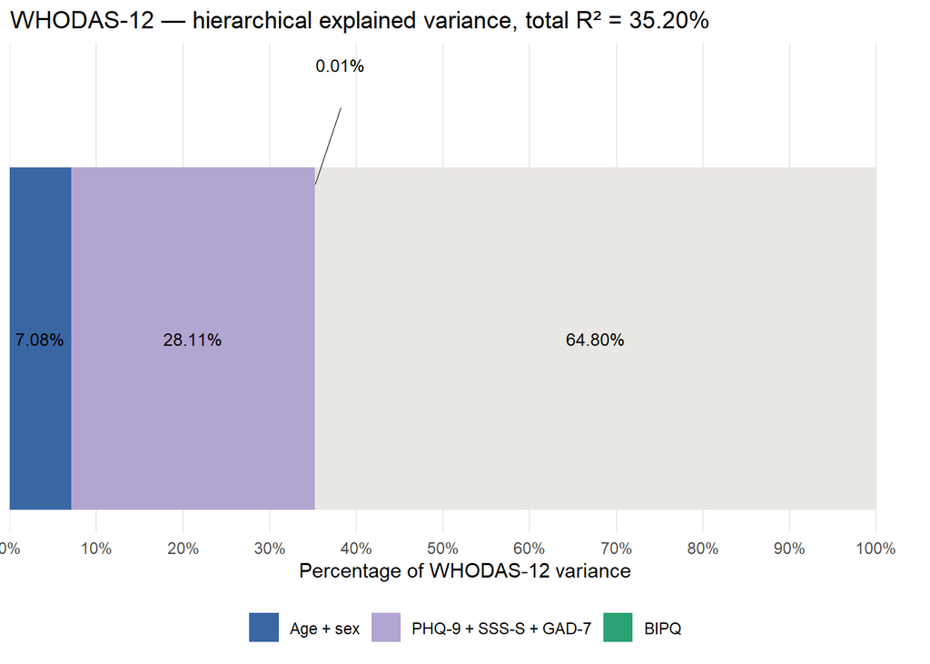

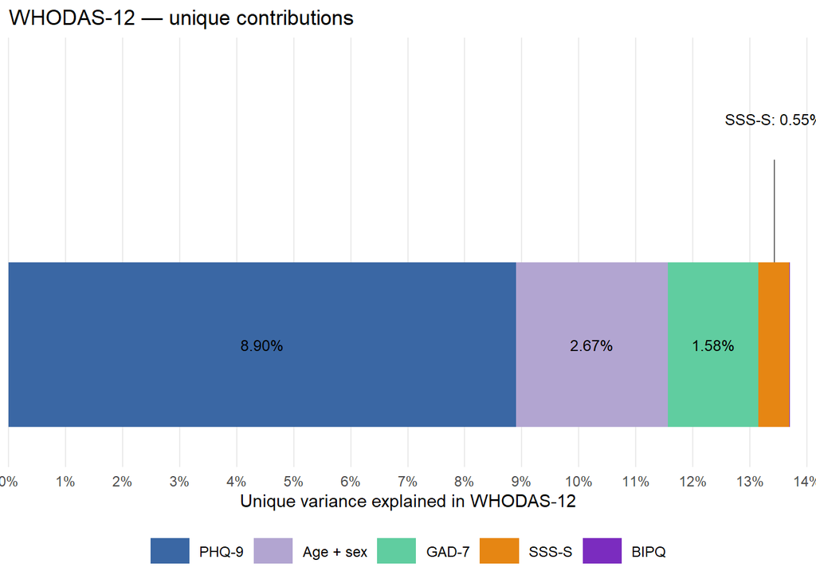

## with yhat

Commonality analysis

```r
# Modèle final
res_lm <- lm(
  Score_whodas ~ age + Sexe + score_PHQ9 + Score_autostigma + score_GAD7 + Score_BIPQ,
  data = dat_clean
)

# Commonality analysis
res_common <- calc.yhat(res_lm)

# Bootstrap 1000 resamples
boot_out <- boot(
  data = dat_clean,
  statistic = yhat::boot.yhat,
  R = 1000,
  lmOut = res_lm,
  regrout0 = res_common
)

# IC 95% percentile
boot_results <- booteval.yhat(
  res_common,
  boot_out,
  bty = "perc",
  .95,
  3
)

# Results
print(res_common$PredictorMetrics)
```

```
##                       b   Beta      r     rs   rs2 Unique Common  CD:0  CD:1
## age              -0.082 -0.123 -0.240 -0.404 0.163  0.014  0.043 0.057 0.040
## SexeM            -2.119 -0.095 -0.156 -0.262 0.069  0.009  0.016 0.024 0.020
## score_PHQ9        0.634  0.406  0.548  0.924 0.855  0.089  0.212 0.301 0.224
## Score_autostigma  0.104  0.086  0.291  0.490 0.240  0.005  0.079 0.084 0.047
## score_GAD7        0.249  0.145  0.389  0.655 0.429  0.016  0.135 0.151 0.095
## Score_BIPQ        0.008  0.010  0.357  0.602 0.362  0.000  0.127 0.127 0.071
## Total                NA     NA     NA     NA 2.118  0.133  0.612 0.744 0.497
##                   CD:2  CD:3  CD:4  CD:5 GenDom Pratt   RLW
## age              0.029 0.022 0.017 0.014  0.030 0.030 0.031
## SexeM            0.016 0.013 0.011 0.009  0.015 0.015 0.016
## score_PHQ9       0.169 0.132 0.107 0.089  0.170 0.223 0.163
## Score_autostigma 0.025 0.013 0.008 0.005  0.030 0.025 0.033
## score_GAD7       0.059 0.037 0.024 0.016  0.064 0.056 0.066
## Score_BIPQ       0.036 0.015 0.005 0.000  0.043 0.004 0.042
## Total            0.334 0.232 0.172 0.133  0.352 0.353 0.351
```

```r
print(res_common$OrderedPredictorMetrics)
```

```
##                  b Beta r rs rs2 Unique Common CD:0 CD:1 CD:2 CD:3 CD:4 CD:5
## age              5    3 5  5   5      3      5    5    5    4    3    3    3
## SexeM            1    4 6  6   6      4      6    6    6    6    5    4    4
## score_PHQ9       2    1 1  1   1      1      1    1    1    1    1    1    1
## Score_autostigma 4    5 4  4   4      5      4    4    4    5    6    5    5
## score_GAD7       3    2 2  2   2      2      2    2    2    2    2    2    2
## Score_BIPQ       6    6 3  3   3      6      3    3    3    3    4    6    6
##                  GenDom Pratt RLW
## age                   4     3   5
## SexeM                 6     5   6
## score_PHQ9            1     1   1
## Score_autostigma      5     4   4
## score_GAD7            2     2   2
## Score_BIPQ            3     6   3
```

```r
print(res_common$PairedDominanceMetrics)
```

```
##                             Comp Cond Gen
## age>Sexe                     1.0  1.0   1
## age>score_PHQ9               0.0  0.0   0
## age>Score_autostigma         0.5  0.5   0
## age>score_GAD7               0.5  0.0   0
## age>Score_BIPQ               0.5  0.5   0
## Sexe>score_PHQ9              0.0  0.0   0
## Sexe>Score_autostigma        0.5  0.5   0
## Sexe>score_GAD7              0.0  0.0   0
## Sexe>Score_BIPQ              0.5  0.5   0
## score_PHQ9>Score_autostigma  1.0  1.0   1
## score_PHQ9>score_GAD7        1.0  1.0   1
## score_PHQ9>Score_BIPQ        1.0  1.0   1
## Score_autostigma>score_GAD7  0.0  0.0   0
## Score_autostigma>Score_BIPQ  0.5  0.5   0
## score_GAD7>Score_BIPQ        1.0  1.0   1
```

```r
# Incremental contribution of the BIPQ to WHODAS-12 explained variance
bipq_incremental <- boot_results$combCIaps[
  "age,Sexe,score_PHQ9,Score_autostigma,score_GAD7",
  "Score_BIPQ.Inc"
]

print(bipq_incremental)
```

```
## [1] "0.000(0.000,0.002)"
```